# TALLER 4

María Paula Camargo Rincon

2026-06-14

# 1 Redes de poder en Colombia

La base de datos poder disponible en la página web del curso corresponde a una red bipartita que relaciona funcionarios públicos con las entidades públicas en las que fueron nombrados a lo largo de seis gobiernos de Colombia, Uribe 1, Uribe 2, Santos 1, Santos 2, Duque y Petro. Específicamente, estos datos se representan mediante una matriz bipartita $\mathbf{A}=[a_{i,j}]$ de tamaño $n\times m$, donde $n$ representa el número de funcionarios y $m$ el número de entidades públicas. En esta matriz, $a_{i,j}=1$ si el funcionario $i$ fue nombrado en la entidad $j$, y $a_{i,j}=0$ en caso contrario. La base también incluye covariables individuales, como EDAD, GENERO, PARTIDO_POLITICO, NIVEL_DE_ESTUDIOS, UNIVERSIDAD, CARRERA y GOBERNACION. Esta informacion fue diseñada y recolectada junto con el estudiante Johan Andrés Hernández Sarmiento como parte de su trabajo de grado. La base tiene carácter estrictamente confidencial, por lo que ninguna persona cuenta con autorizacion para compartirla, reproducirla o divulgarla.

El objetivo es llevar a cabo un análisis exhaustivo de las redes de poder en Colombia a través de distintos gobiernos. En el artículo Estos son los grupos políticos que sostienen al gobierno Petro y sus puntos de tension, los autores desarrollan un ejercicio similar, aunque a una escala mucho menor y con recursos teoricos, empíricos y metodologicos más limitados desde el punto de vista del análisis de redes. A pesar de su simplicidad técnica, este texto constituye un buen punto de partida para comprender el proposito general de este caso de estudio.

## 1.1 a. Filtre la base de datos usando la covariable GOBERNACION, de manera que se conserven todos aquellos funcionarios que hicieron parte del Gobierno Petro, incluso si también participaron en otros gobiernos. Sea $\mathbf{A}_{P}$ la matriz bipartita resultante de este filtro, de tamaño $n_P\times m$, donde $n_P$ corresponde al número de funcionarios del Gobierno Petro y $m$ corresponde al número de entidades públicas. A partir de esta matriz, construya la matriz de adyacencia ponderada $\mathbf{A}_{P}\mathbf{A}_{P}^{T}$, de tamaño $n_P\times n_P$. Luego, construya la matriz $\mathbf{Y}_P$ a partir de esta matriz de adyacencia ponderada, transformándola en una matriz binaria y fijando en cero los elementos de la diagonal principal. Repita este procedimiento para los gobiernos Duque, Santos y Uribe. En los casos de Santos y Uribe, combine los dos periodos de cada gobierno en una sola matriz. Al finalizar el proceso, debe contar con cuatro redes binarias no dirigidas, una para cada gobierno.

```r
poder <- read_excel("poder.xlsx",
    sheet = "GABINETE_LIMPIO")
poder$EDAD <- as.numeric(poder$EDAD)
```

```r
entidades <- names(poder)[2:51]
crear_red <- function(datos, gobierno) {

  datos_gob <- datos  %>%
    filter(stringr::str_detect(GOBERNACION, gobierno))

  datos_gob <- datos_gob  %>%
  mutate(
    partido_plot = case_when(
      PARTIDO_POLITICO %in% c("PACTO HISTORICO", "PACTO HISTÓRICO") ~ "Pacto Histórico",

      PARTIDO_POLITICO %in% c("CENTRO DEMOCRATICO", "CENTRO DEMOCRÁTICO") ~ "Centro Democrático",

      PARTIDO_POLITICO %in% c("PARTIDO LIBERAL",
                              "PARTIDO LIBERAL COLOMBIANO") ~ "Liberal",

      PARTIDO_POLITICO %in% c("PARTIDO CONSERVADOR",
                              "PARTIDO CONSERVADOR COLOMBIANO") ~ "Conservador",

      PARTIDO_POLITICO %in% c("PARTIDO DE LA U",
                              "PARTIDO SOCIAL DE UNIDAD NACIONAL") ~ "Partido de la U",

      PARTIDO_POLITICO %in% c("CAMBIO RADICAL") ~ "Cambio Radical",

      TRUE ~ "Otros"
    )
  )

  nombres_petro <- datos_gob[[1]]

  A <- datos_gob %>%
    select(all_of(entidades)) %>%
    mutate(across(everything(), as.numeric)) %>%
    as.matrix()

  rownames(A) <- nombres_petro

  W <- A %*% t(A)

  Y <- ifelse(W > 0, 1, 0)

  diag(Y) <- 0

  return(list(adyacencia=Y,datos_gob=datos_gob))
}
y_petro <- crear_red(datos = poder,gobierno = "PETRO")
y_duque <- crear_red(datos = poder,gobierno = "DUQUE")
y_santos <- crear_red(datos = poder,gobierno = "SANTOS")
y_uribe <- crear_red(datos = poder,gobierno = "URIBE")
```

## 1.2 b. De manera paralela y comparativa, construya visualizaciones decoradas para cada red, aprovechando al máximo la informacion nodal disponible. Presente estas visualizaciones de forma estratégica, de modo que faciliten la comparacion entre gobiernos y permitan identificar patrones comunes, diferencias estructurales y posibles cambios en la configuracion de las redes de poder.

```r
crear_grafo <- function(Y, datos_gob) {

  g <- graph_from_adjacency_matrix(
    Y,
    mode = "undirected",
    diag = FALSE
  )

  V(g)$nombre <- datos_gob[[1]]
  V(g)$partido <- datos_gob$partido_plot
  V(g)$genero <- datos_gob$GENERO
  V(g)$edad <- datos_gob$EDAD
  V(g)$nivel_estudios <- datos_gob$NIVEL_DE_ESTUDIOS
  V(g)$carrera <- datos_gob$CARRERA
  V(g)$universidad <- datos_gob$UNIVERSIDAD
  V(g)$predecesores <- datos_gob$PREDECESORES
  V(g)$grado <- degree(g)

  g
}
g_petro  <- crear_grafo(y_petro$adyacencia, y_petro$datos_gob)

g_duque  <- crear_grafo(y_duque$adyacencia, y_duque$datos_gob)

g_santos <- crear_grafo(y_santos$adyacencia, y_santos$datos_gob)

g_uribe  <- crear_grafo(y_uribe$adyacencia, y_uribe$datos_gob)

graficar_red <- function(g, titulo){

  ggraph(g, layout = "fr") +

    geom_edge_link(
      alpha = .25,
      colour = "grey70"
    ) +

    geom_node_point(
      aes(
        colour = genero,
        shape = partido,
        size = grado
      )
    ) + scale_shape_manual(
  values = c(
    "Pacto Histórico" = 16,      # círculo
    "Centro Democrático" = 17,   # triángulo
    "Partido de la U" = 15,      # cuadrado
    "Liberal" = 18,              # rombo
    "Conservador" = 8,           # estrella
    "Cambio Radical" = 3,        # cruz
    "Otros" = 7                  # cuadrado con cruz
  )
) + guides(
  shape = guide_legend(nrow = 3, direction = "vertical"),
  colour = guide_legend(nrow = 2, direction = "vertical"),
  size=guide_legend(direction = "vertical")
)   +


    labs(title = titulo) +

    theme_minimal() +

    theme(
      legend.position = "bottom"
    )
}

p1 <- graficar_red(g_petro, "Petro")
p2 <- graficar_red(g_duque, "Duque")
p3 <- graficar_red(g_santos, "Santos")
p4 <- graficar_red(g_uribe, "Uribe")
```

### 1.2.1 Petro

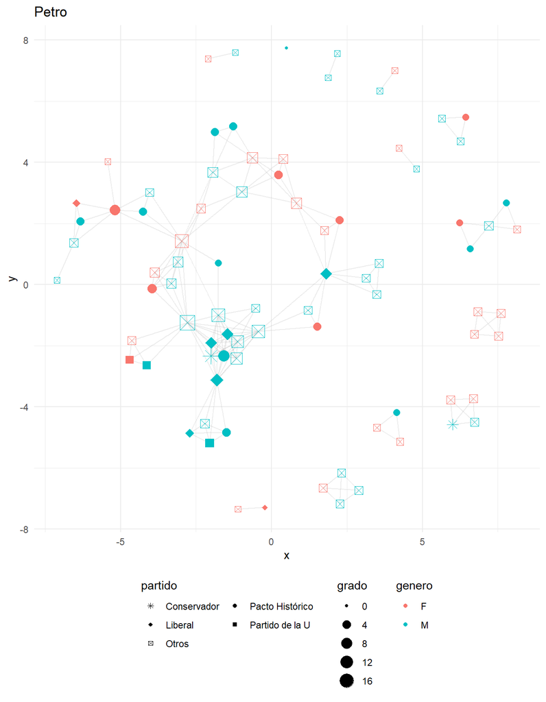

Figure 1.1: Red de funcionarios del Gobierno Petro.

```r
p1
```

### 1.2.2 Duque

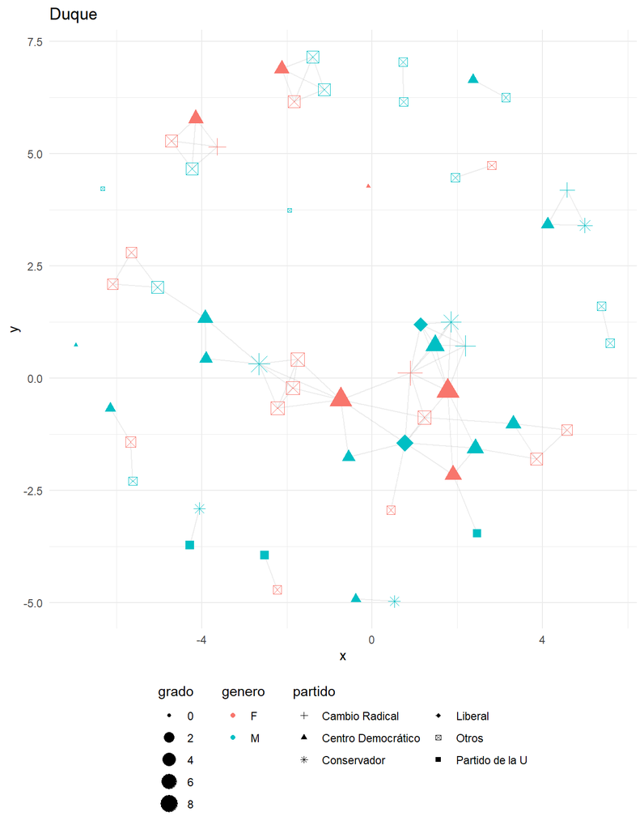

Figure 1.2: Red de funcionarios del Gobierno Duque

```r
p2
```

### 1.2.3 Santos

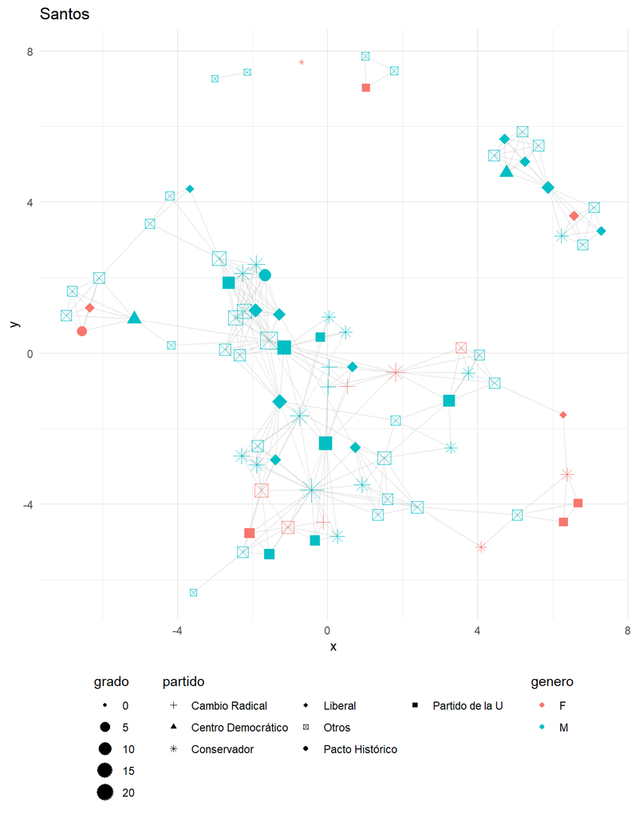

Figure 1.3: Red de funcionarios del Gobierno Santos.

```r
p3
```

### 1.2.4 Uribe

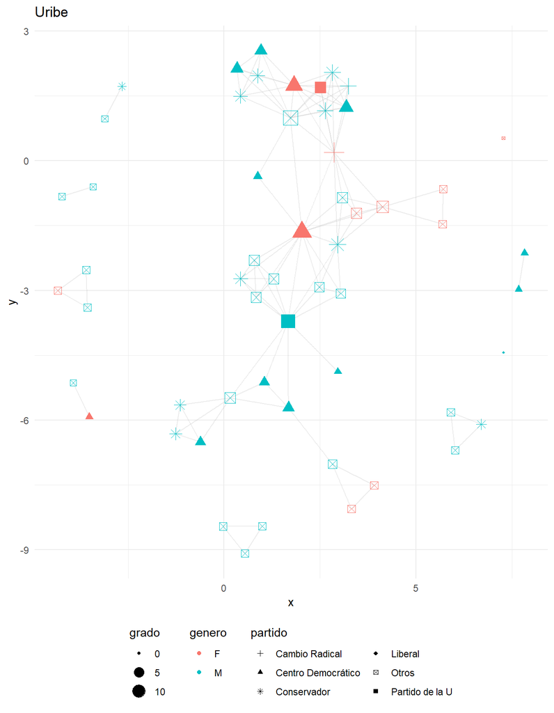

Figure 1.4: Red de funcionarios del Gobierno Uribe.

```r
p4
```

## 1.3 Discusión

- En la red del gobierno de Gustavo Petro se observa una proporción visual similar de hombres y mujeres. Aunque el presidente pertenece al **Pacto Histórico**, la red de funcionarios está conformada principalmente por miembros de partidos distintos a los tradicionales. Además, se evidencia la ausencia de integrantes del **Centro Democrático** y de **Cambio Radical**. En general, todos los partidos representados parecen tener cierta participación en la red, ya que cada uno cuenta con al menos algunos nodos de tamaño relativamente mayor (determinado por el grado).
- En el gobierno de Iván Duque también se aprecia una proporción visual similar de hombres y mujeres. Aunque la red está integrada mayoritariamente por miembros de partidos distintos a los tradicionales, los nodos con mayor grado pertenecen en su mayoría al **Centro Democrático**, partido del que hacía parte el presidente. Esto podría sugerir una mayor centralidad de funcionarios de este partido dentro de la red. Asimismo, se observa la ausencia de miembros del **Pacto Histórico**.
- En el gobierno de Juan Manuel Santos (considerando sus dos periodos presidenciales) se observa una mayor proporción de hombres que de mujeres. La red incluye representantes de todos los partidos analizados y está conformada principalmente por miembros de partidos distintos a los tradicionales. Sin embargo, los nodos con mayor grado pertenecen en su mayoría al **Partido de la U**, colectividad de la cual Santos fue cofundador, lo que podría reflejar una mayor centralidad de sus integrantes en la estructura de la red.
- En el gobierno de Álvaro Uribe (considerando sus dos periodos presidenciales) también se evidencia una mayor proporción de hombres que de mujeres. Aunque la red está integrada principalmente por miembros de partidos distintos a los tradicionales, los nodos más centrales corresponden en su mayoría al **Centro Democrático**, partido con el que se encuentra asociado el expresidente. Este patrón podría ser consistente con una mayor presencia de funcionarios de dicha colectividad en posiciones centrales de la red. Asimismo, se observa la ausencia de miembros del **Pacto Histórico**.

## 1.4 c. Calcule medidas de centralidad para identificar cuáles son los funcionarios más influyentes dentro de cada red. A partir de estos resultados, construya visualizaciones decoradas que incorporen la informacion de centralidad de manera clara e informativa. Presente las visualizaciones de forma estratégica para comparar los resultados entre gobiernos. Finalmente, interprete los hallazgos de manera profunda, pero concisa, destacando sus posibles implicaciones políticas.

```r
medidas_1ccentralidad %>%
  kableExtra::kbl(
    caption = "Resultados",
    digits = 3
  ) %>%
  kableExtra::add_header_above(
    header = c(
      " " = 1,
      stats::setNames(
        rep(2, length(redes_poder)),
        names(redes_poder)
      )
    )
  ) %>%
  kableExtra::kable_minimal()
```

Table 1.1: Resultados

| Medidas / Departamentos | Petro Media | Petro Desviacion Estandar | Duque Media | Duque Desviacion Estandar | Santos Media | Santos Desviacion Estandar | Uribe Media | Uribe Desviacion Estandar |
| --- | --- | --- | --- | --- | --- | --- | --- | --- |
| Grado | 0.051 | 0.040 | 0.047 | 0.036 | 0.078 | 0.046 | 0.075 | 0.061 |
| Cercania | 0.595 | 0.312 | 0.675 | 0.325 | 0.441 | 0.196 | 0.565 | 0.303 |
| Intermediacion | 0.008 | 0.025 | 0.007 | 0.018 | 0.014 | 0.033 | 0.015 | 0.040 |
| Propio | 0.148 | 0.284 | 0.157 | 0.276 | 0.185 | 0.253 | 0.218 | 0.293 |

- **Grado.** Los cuatro gobiernos presentan un grado medio relativamente bajo (entre 0.047 y 0.078), lo que indica que, en promedio, los funcionarios están conectados con una pequeña proporción de los demás actores de la red. Santos y Uribe presentan los mayores grados medios, sugiriendo redes ligeramente más conectadas. La desviación estándar es considerable respecto a la media, lo que indica que existen actores mucho más conectados que otros.
- **Cercanía.** Duque presenta la mayor cercanía promedio (0.675), seguido por Petro (0.595), mientras que Santos registra la menor (0.441). Esto sugiere que, en promedio, los funcionarios del gobierno de Duque pueden alcanzar al resto de actores mediante caminos más cortos que en los demás gobiernos. Las desviaciones estándar (entre 0.196 y 0.325) muestran que esta capacidad no es uniforme entre los nodos.
- **Intermediación.** Los valores promedio son bajos en todos los gobiernos (0.007–0.015), indicando que la mayoría de los actores rara vez actúan como puentes entre otros. No obstante, las desviaciones estándar superan incluso la media, lo que sugiere que unos pocos nodos concentran gran parte de la intermediación mientras la mayoría tiene valores cercanos a cero.
- **Centralidad de vector propio (eigenvector).** Uribe presenta el mayor promedio (0.218), seguido por Santos (0.185), Duque (0.157) y Petro (0.148). Esto indica que, en promedio, los actores de la red de Uribe están algo más conectados con otros actores importantes. De nuevo, las desviaciones estándar relativamente altas evidencian una distribución desigual de esta centralidad.

## 1.5 d. Analice cada una de las redes a nivel local y estructural mediante métricas de distancia, cohesion, conectividad y agrupamiento. Emplee un conjunto amplio de métricas que permita caracterizar de manera detallada las propiedades principales de cada red. Presente los resultados de forma estratégica, de modo que se facilite la comparacion entre gobiernos y se identifiquen similitudes, diferencias y cambios relevantes en la estructura de las redes de poder. Finalmente, interprete los hallazgos de manera profunda, pero concisa, destacando sus posibles implicaciones políticas.

El análisis de cada métrica está dentro de cada pestaña.

### 1.5.1 Distancia

```r
tabla2cdistancia %>%
  kableExtra::kbl(caption='Resultados',
                  digits=3) %>%
  kableExtra::kable_minimal()
```

Table 1.2: Resultados

| Medidas.departamento | Petro | Duque | Santos | Uribe |
| --- | --- | --- | --- | --- |
| Orden | 83 | 58 | 85 | 56 |
| Tamaño | 172 | 77 | 278 | 116 |
| Orden de la componente gigante | 49 | 26 | 67 | 37 |
| Diámetro del grafo | 7 | 7 | 7 | 6 |
| Camino del diámetro | GERMAN AVILA PLAZAS;JOSE ANTONIO OCAMPO GAVIRIA;CECILIA MATILDE LOPEZ MONTANO;LUIS GILBERTO MURILLO URRUTIA;LAURA CAMILA SARABIA TORRES;CIELO ELAINNE RUSINQUE URREGO;LUIS CARLOS REYES HERNANDEZ;JAIRO … | ANGELICA MARIA MAYOLO OBREGON;PEDRO FELIPE BUITRAGO RESTREPO;MARIA ADRIANA MEJIA HERNANDEZ;MARTA LUCIA RAMIREZ BLANCO;JOSE MANUEL RESTREPO ABONDANO;ALBERTO CARRASQUILLA BARRERA;LUIS ALBERTO RODRIGUEZ … | YANETH CRISTINA GIHA TOVAR;MARIA FERNANDA CAMPO SAAVEDRA;MARIA ANGELA HOLGUIN CUELLAR;LUIS GILBERTO MURILLO URRUTIA;BEATRIZ URIBE BOTERO;GERMAN VARGAS LLERAS;ANGELINO GARZON;GRISELDA JANETH RESTREPO G… | SANDRA SUAREZ PEREZ;CARLOS R. COSTA POSADA;ALBERTO CARRASQUILLA BARRERA;JUAN MANUEL SANTOS CALDERON;MARTA LUCIA RAMIREZ BLANCO;CLAUDIA BLUM CAPURRO DE BARBERI;NANCY PATRICIA GUTIERREZ CASTANEDA |
| distancia media | 2.89 | 2.849 | 2.873 | 2.814 |

Las cuatro redes presentan cierto grado de fragmentación, ya que la componente gigante no incluye a la totalidad de los actores. No obstante, el gobierno de Santos es el menos fragmentado, pues cerca del 79 % de los nodos pertenecen a la componente principal, seguido por Uribe (66 %), Petro (59 %) y Duque (45 %), siendo este último el gobierno con mayor fragmentación. En cuanto a las distancias geodésicas, las cuatro redes muestran valores muy similares: la distancia media se sitúa alrededor de tres pasos y el diámetro varía únicamente entre seis y siete. Esto sugiere que, dentro de las componentes conectadas, los actores pueden alcanzarse mediante pocos intermediarios y que la extensión máxima de las rutas más largas es comparable entre todos los gobiernos.

### 1.5.2 Cohesión

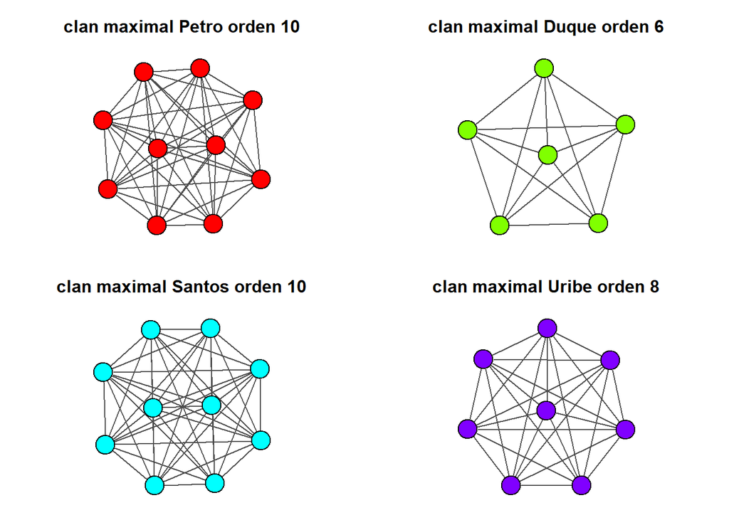

```r
colores <- rainbow(length(redes_poder))
# frecuencias de clanes
tabla_cliques <- list()
for (i in 1:length(redes_poder)) {
  tabla_cliques[[i]] <- sapply(
  X = 1:clique_num(redes_poder[[i]]),
  FUN = \(k) {
    igraph::count_max_cliques(redes_poder[[i]], min = k, max = k)
  }
)

tabla_cliques[[i]] <- data.frame(
  clique=seq(1:length(tabla_cliques[[i]])),
  frecuencia=tabla_cliques[[i]]
)

tabla_cliques[[i]] <- tabla_cliques[[i]] %>% filter(frecuencia!=0)
}

densidad2c <- data.frame(Valor='Densidad')
par(mfrow = c(2, 2), mar = c(1, 1, 3, 1))
for (j in 1:length(redes_poder)) {
  clanes_maximal <- lapply(seq_along(largest_cliques(redes_poder[[j]])), function(k){
  i <- largest_cliques(redes_poder[[j]])[[k]]
  clan_maximal <- induced_subgraph(graph = redes_poder[[j]],vids = i)
  plot(clan_maximal, main=paste("clan maximal", names(redes_poder)[j],'orden',vcount(clan_maximal),sep=' '),
       vertex.size        = 25,
       vertex.label = '',
     #vertex.label.color = "black",
     vertex.color       = colores[j],
     vertex.frame.color = "black",
     edge.color         = "gray30")
})
  g <- redes_poder[[j]]

  # componente gigante
  comp <- components(g)
  giant_id <- which(comp$membership == which.max(comp$csize))
  g_gc <- induced_subgraph(g, giant_id)

  df <- data.frame(densidad=edge_density(g_gc))
  names(df) <- names(redes_poder)[j]
  densidad2c <- cbind(densidad2c,df)
}
```

```r
names(densidad2c)[1] <- ''
```

```r
names(tabla_cliques[[1]]) <- c('Tamaño clique','cantidad de cliques')
  tabla_cliques[[1]] %>%
    kableExtra::kbl(
      caption = paste(
        "Clanes y su Frecuencia para",
        names(redes_poder)[1]
      ),
      digits = 3,
      format = 'html'
    ) %>%
    kableExtra::kable_minimal()
```

Table 1.3: Clanes y su Frecuencia para Petro

| Tamaño clique | cantidad de cliques |
| --- | --- |
| 1 | 1 |
| 2 | 7 |
| 3 | 8 |
| 4 | 12 |
| 5 | 2 |
| 6 | 1 |
| 10 | 1 |

```r
names(tabla_cliques[[2]]) <- c('Tamaño clique','cantidad de cliques')
  tabla_cliques[[2]] %>%
    kableExtra::kbl(
      caption = paste(
        "Clanes y su Frecuencia para",
        names(redes_poder)[2]
      ),
      digits = 3,
      format = 'html'
    ) %>%
    kableExtra::kable_minimal()
```

Table 1.4: Clanes y su Frecuencia para Duque

| Tamaño clique | cantidad de cliques |
| --- | --- |
| 1 | 4 |
| 2 | 14 |
| 3 | 6 |
| 4 | 4 |
| 5 | 1 |
| 6 | 1 |

```r
names(tabla_cliques[[3]]) <- c('Tamaño clique','cantidad de cliques')
  tabla_cliques[[3]] %>%
    kableExtra::kbl(
      caption = paste(
        "Clanes y su Frecuencia para",
        names(redes_poder)[3]
      ),
      digits = 3,
      format = 'html'
    ) %>%
    kableExtra::kable_minimal()
```

Table 1.5: Clanes y su Frecuencia para Santos

| Tamaño clique | cantidad de cliques |
| --- | --- |
| 1 | 1 |
| 2 | 6 |
| 3 | 8 |
| 4 | 3 |
| 5 | 1 |
| 6 | 5 |
| 7 | 3 |
| 8 | 2 |
| 10 | 1 |

```r
names(tabla_cliques[[4]]) <- c('Tamaño clique','cantidad de cliques')
  tabla_cliques[[4]] %>%
    kableExtra::kbl(
      caption = paste(
        "Clanes y su Frecuencia para",
        names(redes_poder)[4]
      ),
      digits = 3,
      format = 'html'
    ) %>%
    kableExtra::kable_minimal()
```

Table 1.6: Clanes y su Frecuencia para Uribe

| Tamaño clique | cantidad de cliques |
| --- | --- |
| 1 | 2 |
| 2 | 6 |
| 3 | 7 |
| 4 | 2 |
| 5 | 1 |
| 6 | 3 |
| 8 | 1 |

```r
densidad2c %>%
  kableExtra::kbl(
    caption = "Densidad de las componentes gigantes de los gobiernos",
    digits = 3
  ) %>%
  kableExtra::kable_minimal()
```

Table 1.7: Densidad de las componentes gigantes de los gobiernos

|  | Petro | Duque | Santos | Uribe |
| --- | --- | --- | --- | --- |
| Densidad | 0.116 | 0.163 | 0.108 | 0.155 |

En los cuatro gobiernos, la mayor parte de los cliques maximales corresponde a grupos pequeños de entre uno y tres actores. No obstante, existen diferencias en los cliques de mayor tamaño. El gobierno de Duque destaca por presentar 14 cliques de dos actores, mientras que Petro sobresale por contar con 12 cliques de cuatro actores. Por su parte, Santos presenta cinco cliques de seis actores y, además, concentra una mayor cantidad de cliques de siete y ocho actores, a pesar de ser la red con menor densidad global. Esto sugiere que, aunque la red de Santos es menos densa en términos generales, contiene varios subgrupos altamente cohesionados.

### 1.5.3 Conectividad

```r
tabla.1cconectividad %>%
  kableExtra::kbl(caption = 'Comparación de métricas de conectividad',
                    digits = 3) %>%
  kableExtra::kable_minimal()
```

Table 1.8: Comparación de métricas de conectividad

| Medidas | Petro | Duque | Santos | Uribe |
| --- | --- | --- | --- | --- |
| ¿Está conectado | FALSE | FALSE | FALSE | FALSE |
| Conectividad nodal | 0 | 0 | 0 | 0 |
| Conectividad por aristas | 0 | 0 | 0 | 0 |
| Puntos de artículación | OSCAR MAURICIO LIZCANO ARANGO;JOSE ANTONIO OCAMPO GAVIRIA;MIGUEL ANGEL PINTO HERNANDEZ;LUIS CARLOS REYES HERNANDEZ;CIELO ELAINNE RUSINQUE URREGO;LAURA CAMILA SARABIA TORRES;ALEJANDRO GAVIRIA URIBE | CARLOS HOLMES TRUJILLO GARCIA;ALICIA VICTORIA ARANGO OLMOS;LUIS ALBERTO RODRIGUEZ OSPINO;ALBERTO CARRASQUILLA BARRERA;JOSE MANUEL RESTREPO ABONDANO;MARTA LUCIA RAMIREZ BLANCO;SUSANA CORREA BORRERO | SANTIAGO ROJAS ARROYO;JUAN CARLOS ESGUERRA PORTOCARRERO | MARIA CONSUELO ARAUJO CASTRO;CARLOS R. COSTA POSADA;ALBERTO CARRASQUILLA BARRERA;ROBERTO JUNGUITO BONNET;JUAN MANUEL SANTOS CALDERON |

Ninguna de las cuatro redes es conexa, por lo que tanto la conectividad nodal como la conectividad por aristas son iguales a cero. No obstante, todas presentan puntos de articulación, es decir, actores cuya eliminación incrementaría la fragmentación de la componente a la que pertenecen. Este patrón se observa incluso en las redes con mayor densidad (Duque y Uribe), lo que sugiere que una mayor densidad global no necesariamente implica una estructura más robusta frente a la eliminación de actores clave. En estas redes existen funcionarios que desempeñan un papel fundamental como puentes entre distintos grupos.

### 1.5.4 Agrupamiento

```r
tabla.1ctransitividadg %>%
  kableExtra::kbl(caption = 'Comparación transitividad global en los diferentes gobiernos',
                    digits = 3) %>%
  kableExtra::kable_minimal()
```

Table 1.9: Comparación transitividad global en los diferentes gobiernos

|  | Petro | Duque | Santos | Uribe |
| --- | --- | --- | --- | --- |
| Transitividad global | 0.652 | 0.629 | 0.639 | 0.629 |

```r
tabla.1ctransitividadg <- lapply(
  redes_poder,
  function(g) {

    valores <- transitivity(
      graph = g,
      type = "local"
    )

    valores[is.nan(valores)] <- NA

    return(valores)
  }
)

graficos <- vector("list", length(redes_poder))
for (i in 1:length(tabla.1ctransitividadg)) {
  trans_global <- transitivity(
    graph = redes_poder[[i]],
    type = 'global'
  )
  df <- data.frame(
    transitividad=tabla.1ctransitividadg[[i]]
  )
  graficos[[i]] <- ggplot2::ggplot(data = df,
                  mapping = aes(x = transitividad))+
    ggplot2::geom_histogram(col ='gray24', fill = colores[i])+
    ggplot2::labs(
    title = names(tabla.1ctransitividadg)[i],
    x = "Transitividad local",
    y = "Frecuencia"
  ) +
    geom_vline(
    aes(
      xintercept = trans_global,
      color = "Global"
    ),
    linewidth = 1.2
  )   +
    ggplot2::annotate(
      "text",
      x = trans_global,
      y = Inf,
      label = round(trans_global, 3),
      vjust = 2,
      color = "black"
    ) +
  scale_color_manual(
    name = "",
    values = c("Global" = "gray49")
  ) +
  theme_minimal()
}
```

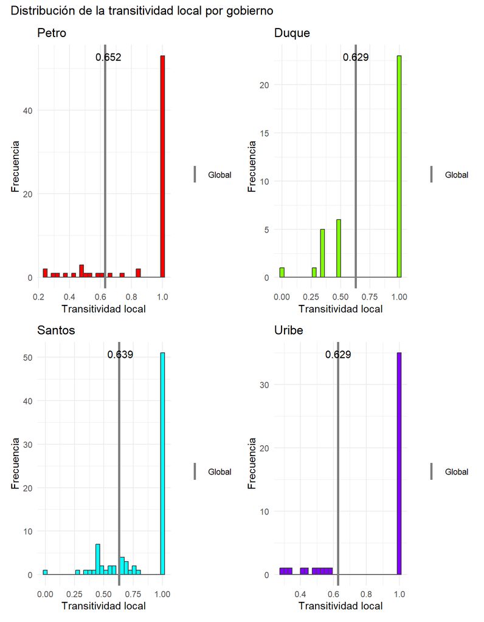

Figure 1.5: Distribución de la transitividad local por gobiernos

```r
(graficos[[1]] | graficos[[2]]) /
(graficos[[3]] | graficos[[4]])+
  plot_annotation(
    title = "Distribución de la transitividad local por gobierno"
  )
```

Los cuatro gobiernos presentan niveles similares de transitividad global, con valores entre 0.629 y 0.652, lo que evidencia una elevada tendencia al agrupamiento local de los actores. Además, la distribución de la transitividad local presenta un sesgo hacia la izquierda, indicando que la mayor parte de los nodos posee valores relativamente altos de transitividad, mientras que son pocos los actores con coeficientes bajos. Esto sugiere que los funcionarios suelen formar grupos donde sus vecinos también se encuentran conectados entre sí.

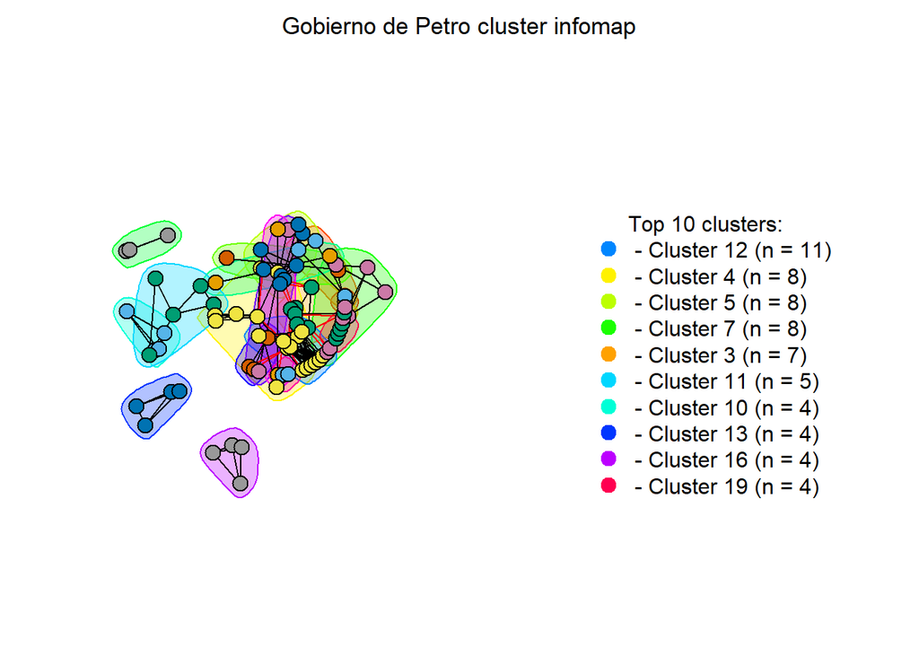

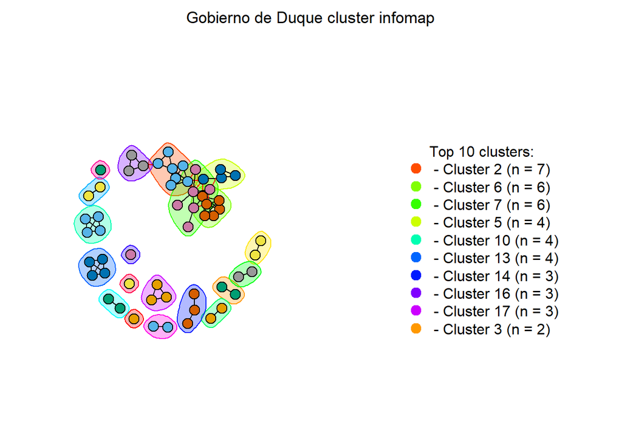

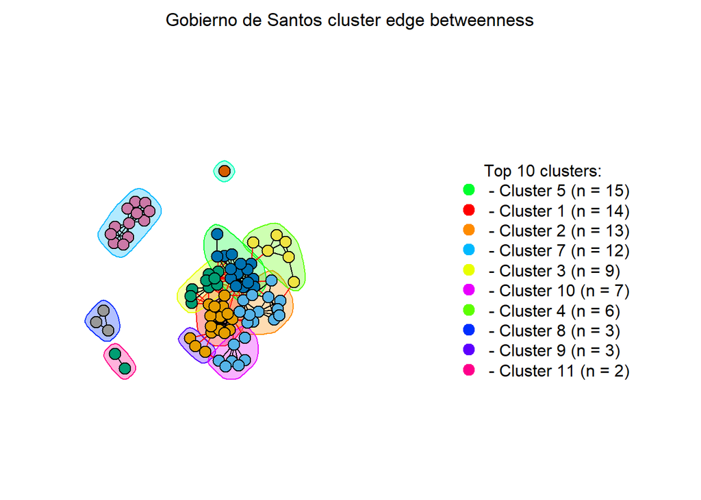

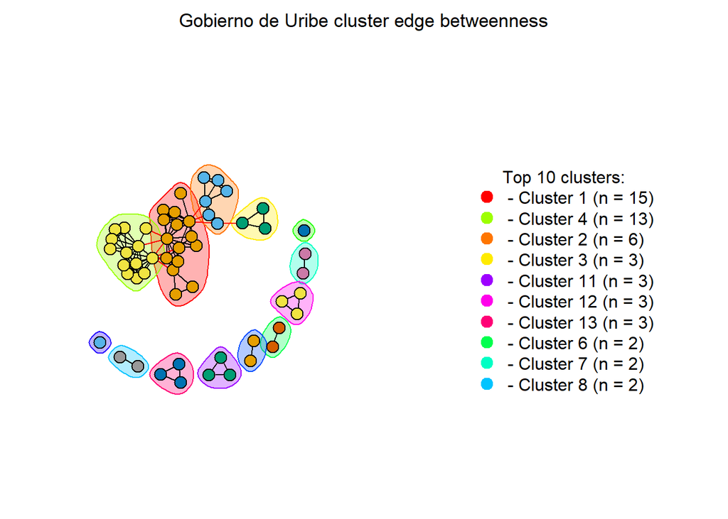

## 1.6 e. Ajuste, de manera independiente para cada red, un modelo de bloques estocásticos, un modelo de grafos aleatorios exponenciales y un modelo de socialidad con covariables. En el caso del modelo de grafos aleatorios exponenciales, incluya como términos del predictor lineal el número de aristas y las covariables con efectos homofílicos. Para el modelo de socialidad, incorpore también covariables con efectos homofílicos. Presente todos los resultados de forma estratégica, de modo que se facilite la comparacion entre gobiernos y se identifiquen diferencias relevantes en la estructura de las redes de poder. Finalmente, interprete los resultados de manera profunda, pero concisa, destacando sus posibles implicaciones políticas.

El análisis esta dentro de cada pestaña.

### 1.6.1 Modelos de bloques estocásticos

#### 1.6.1.1 Resumen

```r
tabla_sbm %>%
  dplyr::select(-"PL") %>%
  kableExtra::kbl(caption = 'Comparación de los modelos de bloques estocásticos para los distintos gobiernos',
                    digits = 3) %>%
  kableExtra::kable_minimal()
```

Table 1.10: Comparación de los modelos de bloques estocásticos para los distintos gobiernos

| gobierno | k_optimo | tamaños | ICL |
| --- | --- | --- | --- |
| Petro | 4 | 16, 16, 41, 10 | -1025.221 |
| Duque | 4 | 8, 13, 6, 31 | -518.507 |
| Santos | 6 | 12, 8, 25, 13, 21, 6 | -1410.508 |
| Uribe | 3 | 31, 12, 13 | -622.999 |

#### 1.6.1.2 Petro

```r
tabla_pi %>%
  dplyr::filter(gobierno=="Petro") %>%
  dplyr::select(-gobierno) %>%
  kableExtra::kbl(caption = 'Probabilidades de interacción para el gobierno de Petro',
                    digits = 3) %>%
  kableExtra::row_spec(c(3,7,11,15), bold = T, color = "white", background = "#B0779E") %>%
  kableExtra::row_spec(16, bold = T, color = "white", background = "#E46923") %>%
  kableExtra::kable_minimal()
```

Table 1.11: Probabilidades de interacción para el gobierno de Petro

| Var1 | Var2 | Freq |
| --- | --- | --- |
| A | A | 0.255 |
| B | A | 0.016 |
| C | A | 0.000 |
| D | A | 0.019 |
| A | B | 0.016 |
| B | B | 0.232 |
| C | B | 0.000 |
| D | B | 0.063 |
| A | C | 0.000 |
| B | C | 0.000 |
| C | C | 0.053 |
| D | C | 0.018 |
| A | D | 0.019 |
| B | D | 0.063 |
| C | D | 0.018 |
| D | D | 0.981 |

Se observa que las comunidades presentan una mayor probabilidad de interacción dentro de sí mismas que con las demás comunidades. En particular, el bloque D destaca por presentar una probabilidad de conexión interna muy alta ($P_{DD}=0.981$), lo que indica una comunidad altamente cohesiva. En contraste, el bloque C exhibe una baja probabilidad de conexión tanto entre sus propios miembros ($P_{CC}=0.053$) como con los demás bloques, lo que sugiere que constituye una comunidad poco conectada con el resto de la red.

#### 1.6.1.3 Duque

```r
tabla_pi %>%
  dplyr::filter(gobierno=="Duque") %>%
  dplyr::select(-gobierno) %>%
  kableExtra::kbl(caption = 'Probabilidades de interacción para el gobierno de Duque',
                    digits = 3) %>%
  kableExtra::row_spec(c(1,6,11), bold = T, color = "white", background = "#E46923") %>%
  kableExtra::kable_minimal()
```

Table 1.12: Probabilidades de interacción para el gobierno de Duque

| Var1 | Var2 | Freq |
| --- | --- | --- |
| A | A | 0.418 |
| B | A | 0.001 |
| C | A | 0.002 |
| D | A | 0.000 |
| A | B | 0.001 |
| B | B | 0.261 |
| C | B | 0.072 |
| D | B | 0.008 |
| A | C | 0.002 |
| B | C | 0.072 |
| C | C | 0.966 |
| D | C | 0.001 |
| A | D | 0.000 |
| B | D | 0.008 |
| C | D | 0.001 |
| D | D | 0.039 |

Al igual que en el gobierno de Petro, las mayores probabilidades de conexión se presentan dentro de las mismas comunidades, lo que indica una preferencia de los nodos por relacionarse con miembros de su propio bloque. En particular, la comunidad C es la más cohesiva, con una probabilidad de interacción interna de 0.966, seguida por las comunidades A (0.418) y B (0.261). En contraste, la comunidad D presenta una baja probabilidad de conexión entre sus integrantes (0.039), lo que sugiere una menor cohesión interna. Asimismo, las probabilidades de interacción entre comunidades son, en general, reducidas, siendo la conexión entre los bloques B y C (0.072) la más alta entre comunidades distintas.

#### 1.6.1.4 Santos

```r
tabla_pi %>%
  dplyr::filter(gobierno=="Santos") %>%
  dplyr::select(-gobierno) %>%
  kableExtra::kbl(caption = 'Probabilidades de interacción para el gobierno de Santos',
                    digits = 3) %>%
  kableExtra::row_spec(c(1,8,22,29,36),
                       bold = T, color = "white", background = "#E46923") %>%
  kableExtra::row_spec(c(12,32), bold = T, color = "white", background = "#B0779E") %>%
  kableExtra::kable_minimal()
```

Table 1.13: Probabilidades de interacción para el gobierno de Santos

| Var1 | Var2 | Freq |
| --- | --- | --- |
| A | A | 0.537 |
| B | A | 0.002 |
| C | A | 0.001 |
| D | A | 0.002 |
| E | A | 0.001 |
| F | A | 0.002 |
| A | B | 0.002 |
| B | B | 0.976 |
| C | B | 0.016 |
| D | B | 0.078 |
| E | B | 0.078 |
| F | B | 0.165 |
| A | C | 0.001 |
| B | C | 0.016 |
| C | C | 0.116 |
| D | C | 0.025 |
| E | C | 0.002 |
| F | C | 0.014 |
| A | D | 0.002 |
| B | D | 0.078 |
| C | D | 0.025 |
| D | D | 0.759 |
| E | D | 0.027 |
| F | D | 0.015 |
| A | E | 0.001 |
| B | E | 0.078 |
| C | E | 0.002 |
| D | E | 0.027 |
| E | E | 0.237 |
| F | E | 0.025 |
| A | F | 0.002 |
| B | F | 0.165 |
| C | F | 0.014 |
| D | F | 0.015 |
| E | F | 0.025 |
| F | F | 0.965 |

Al igual que en los gobiernos de Petro y Duque, las mayores probabilidades de interacción se presentan dentro de las mismas comunidades, destacándose los bloques B ($P_{BB}=0.976$) y F ($P_{FF}=0.965$), que exhiben una alta cohesión interna. Sin embargo, a diferencia de los casos anteriores, en el gobierno de Santos se observan probabilidades de interacción entre comunidades relativamente más altas. En particular, la conexión entre los bloques B y F alcanza una probabilidad de 0.165, mientras que entre B-D y B-E es de 0.078. Esto sugiere que, aunque el modelo identifica un mayor número de comunidades (seis bloques), estas no se encuentran completamente aisladas, sino que mantienen una mayor interacción entre sí.

#### 1.6.1.5 Uribe

```r
tabla_pi %>%
  dplyr::filter(gobierno=="Uribe") %>%
  dplyr::select(-gobierno) %>%
  kableExtra::kbl(caption = 'Probabilidades de interacción para el gobierno de Uribe',
                    digits = 3) %>%
  kableExtra::row_spec(c(5,9), bold = T, color = "white", background = "#E46923") %>%
  kableExtra::kable_minimal()
```

Table 1.14: Probabilidades de interacción para el gobierno de Uribe

| Var1 | Var2 | Freq |
| --- | --- | --- |
| A | A | 0.058 |
| B | A | 0.001 |
| C | A | 0.015 |
| A | B | 0.001 |
| B | B | 0.628 |
| C | B | 0.046 |
| A | C | 0.015 |
| B | C | 0.046 |
| C | C | 0.432 |

Al igual que en los gobiernos anteriores, las probabilidades de interacción son mayores dentro de las comunidades que entre ellas, lo que evidencia una preferencia por establecer conexiones con miembros del mismo bloque. No obstante, a diferencia de los demás gobiernos, ninguna comunidad presenta una cohesión interna tan marcada. Aunque el bloque B registra la mayor probabilidad de interacción dentro de la comunidad ($P_{BB}=0.628$), este valor es considerablemente inferior a los observados en los gobiernos de Petro, Duque y Santos. Asimismo, el bloque A exhibe una baja probabilidad de conexión interna ($P_{AA}=0.058$), mientras que el bloque C presenta una cohesión moderada ($P_{CC}=0.432$). Estos resultados sugieren que, si bien las comunidades identificadas en el gobierno de Uribe están definidas, sus fronteras son menos marcadas y las conexiones se encuentran menos concentradas dentro de cada bloque.

### 1.6.2 Modelos de grafos aleatorios exponenciales

```r
tabla_ergm %>%
  kableExtra::kbl(caption = 'Comparación de los modelos de grafos aleatorios exponenciales para los distintos gobiernos',
                    digits = 3) %>%
  kableExtra::row_spec(
    c(2,5,9,10,11,12,13,16,21,23,27,28),
    color = "#7f8c8d",
    italic = TRUE
  ) %>%
  kableExtra::row_spec(
    c(3,17,24),
    bold = TRUE,
    background = "#CF2F40",
    color = "white"
  ) %>%
  kableExtra::kable_minimal()
```

Table 1.15: Comparación de los modelos de grafos aleatorios exponenciales para los distintos gobiernos

| gobierno | termino | estimacion | error_std | estadistico | p |
| --- | --- | --- | --- | --- | --- |
| Petro | edges | -3.526 | 0.167 | -21.114 | 0.000 |
| Petro | nodematch.partido | -0.015 | 0.159 | -0.096 | 0.923 |
| Petro | nodematch.predecesores | -Inf | 0.000 | -Inf | 0.000 |
| Petro | nodematch.carrera | 0.732 | 0.237 | 3.088 | 0.002 |
| Petro | nodematch.universidad | 0.682 | 0.364 | 1.874 | 0.061 |
| Petro | nodematch.genero | 0.627 | 0.165 | 3.800 | 0.000 |
| Petro | nodematch.nivel_estudios | 0.460 | 0.167 | 2.760 | 0.006 |
| Duque | edges | -3.195 | 0.203 | -15.770 | 0.000 |
| Duque | nodematch.partido | -0.127 | 0.261 | -0.487 | 0.626 |
| Duque | nodematch.predecesores | 2.651 | 1.476 | 1.796 | 0.073 |
| Duque | nodematch.carrera | 0.442 | 0.288 | 1.537 | 0.124 |
| Duque | nodematch.universidad | 1.284 | 0.780 | 1.647 | 0.100 |
| Duque | nodematch.genero | -0.112 | 0.235 | -0.476 | 0.634 |
| Duque | nodematch.nivel_estudios | 0.757 | 0.269 | 2.812 | 0.005 |
| Santos | edges | -3.036 | 0.140 | -21.669 | 0.000 |
| Santos | nodematch.partido | 0.031 | 0.143 | 0.218 | 0.827 |
| Santos | nodematch.predecesores | -Inf | 0.000 | -Inf | 0.000 |
| Santos | nodematch.carrera | 0.698 | 0.164 | 4.259 | 0.000 |
| Santos | nodematch.universidad | 0.779 | 0.358 | 2.179 | 0.029 |
| Santos | nodematch.genero | 0.532 | 0.151 | 3.523 | 0.000 |
| Santos | nodematch.nivel_estudios | 0.296 | 0.160 | 1.853 | 0.064 |
| Uribe | edges | -2.626 | 0.187 | -14.032 | 0.000 |
| Uribe | nodematch.partido | -0.256 | 0.217 | -1.179 | 0.238 |
| Uribe | nodematch.predecesores | -Inf | 0.000 | -Inf | 0.000 |
| Uribe | nodematch.carrera | 0.874 | 0.258 | 3.388 | 0.001 |
| Uribe | nodematch.universidad | 1.168 | 0.495 | 2.359 | 0.018 |
| Uribe | nodematch.genero | -0.003 | 0.204 | -0.015 | 0.988 |
| Uribe | nodematch.nivel_estudios | 0.244 | 0.240 | 1.016 | 0.309 |

- Los resultados indican que compartir el mismo **predecesor** no favorece la formación de vínculos; por el contrario, en tres de los cuatro gobiernos este atributo presenta separación completa, lo que sugiere que prácticamente no existen enlaces entre individuos que comparten un mismo predecesor.
- En el gobierno de **Petro** la probabilidad de formar un vínculo aumenta entre individuos que comparten carrera, género y nivel educativo. Estos resultados son consistentes con la inspección visual de la red (Figura 1.1), donde se observa una mayor tendencia a establecer relaciones entre personas del mismo género.
- En el gobierno de **Duque** únicamente el nivel de estudios presenta un efecto estadísticamente significativo. Esto sugiere que la similitud en la formación académica desempeña un papel importante en la formación de vínculos, mientras que las demás características analizadas no muestran evidencia suficiente de influir en la estructura de la red.
- En el gobierno de **Santos**, aunque la visualización de la red no evidencia una comunidad claramente conformada por mujeres (Figura 1.3), el ERGM indica que el género sí incrementa la probabilidad de establecer vínculos entre individuos del mismo género. Esto refleja que la homofilia por género puede manifestarse localmente sin generar necesariamente comunidades bien definidas.
- En el gobierno de **Uribe** compartir la misma carrera y, especialmente, la misma universidad incrementa la probabilidad de establecer vínculos. Esto sugiere que la formación académica constituye un mecanismo importante en la organización de la red.

### 1.6.3 Modelos de Sociabilidad con covariables

```r
tabla_ame %>%
  kableExtra::kbl(caption = 'Comparación de los modelos de sociabilidad para los distintos gobiernos',
                    digits = 3) %>%
  kableExtra::row_spec(
    c(2,7,8,10,11,12,13,15,16,18,23,26,30,31,32),
    color = "#7f8c8d",
    italic = TRUE
  ) %>%
  kableExtra::kable_minimal()
```

Table 1.16: Comparación de los modelos de sociabilidad para los distintos gobiernos

| gobierno | termino | media | sd | li95 | ls95 |
| --- | --- | --- | --- | --- | --- |
| Petro | Intercepto | -2.184 | 0.113 | -2.414 | -1.963 |
| Petro | Homofilia: Partido | 0.042 | 0.086 | -0.121 | 0.199 |
| Petro | Homofilia: Género | 0.258 | 0.077 | 0.124 | 0.420 |
| Petro | Homofilia: Carrera | 0.357 | 0.128 | 0.102 | 0.627 |
| Petro | Homofilia: Universidad | 0.469 | 0.196 | 0.089 | 0.895 |
| Petro | Homofilia: Nivel de estudios | 0.330 | 0.090 | 0.162 | 0.515 |
| Petro | Homofilia: Predecesores | -8.931 | 8.384 | -22.762 | 3.327 |
| Petro | Edad (\|Δ\| ≤ 5 años) | 0.151 | 0.094 | -0.026 | 0.329 |
| Duque | Intercepto | -2.018 | 0.145 | -2.310 | -1.726 |
| Duque | Homofilia: Partido | 0.052 | 0.145 | -0.247 | 0.309 |
| Duque | Homofilia: Género | -0.011 | 0.113 | -0.235 | 0.201 |
| Duque | Homofilia: Carrera | 0.324 | 0.159 | -0.013 | 0.640 |
| Duque | Homofilia: Universidad | 0.624 | 0.458 | -0.230 | 1.494 |
| Duque | Homofilia: Nivel de estudios | 0.436 | 0.142 | 0.159 | 0.721 |
| Duque | Homofilia: Predecesores | 1.532 | 1.133 | -0.681 | 3.706 |
| Duque | Edad (\|Δ\| ≤ 5 años) | -0.159 | 0.143 | -0.423 | 0.097 |
| Santos | Intercepto | -1.889 | 0.103 | -2.095 | -1.693 |
| Santos | Homofilia: Partido | 0.072 | 0.080 | -0.080 | 0.219 |
| Santos | Homofilia: Género | 0.249 | 0.087 | 0.071 | 0.424 |
| Santos | Homofilia: Carrera | 0.439 | 0.100 | 0.242 | 0.650 |
| Santos | Homofilia: Universidad | 0.432 | 0.203 | 0.023 | 0.864 |
| Santos | Homofilia: Nivel de estudios | 0.182 | 0.088 | 0.011 | 0.341 |
| Santos | Homofilia: Predecesores | -1.782 | 7.266 | -15.008 | 10.732 |
| Santos | Edad (\|Δ\| ≤ 5 años) | 0.147 | 0.074 | 0.013 | 0.303 |
| Uribe | Intercepto | -2.093 | 0.182 | -2.503 | -1.740 |
| Uribe | Homofilia: Partido | 0.114 | 0.118 | -0.105 | 0.349 |
| Uribe | Homofilia: Género | 0.266 | 0.132 | 0.036 | 0.539 |
| Uribe | Homofilia: Carrera | 0.742 | 0.177 | 0.419 | 1.124 |
| Uribe | Homofilia: Universidad | 1.011 | 0.327 | 0.350 | 1.719 |
| Uribe | Homofilia: Nivel de estudios | 0.137 | 0.135 | -0.130 | 0.381 |
| Uribe | Homofilia: Predecesores | 0.746 | 6.409 | -11.248 | 15.683 |
| Uribe | Edad (\|Δ\| ≤ 5 años) | 0.166 | 0.133 | -0.093 | 0.422 |

En general, los modelos de sociabilidad evidencian que la formación de vínculos está asociada principalmente con características académicas y personales de los actores. La homofilia por carrera, universidad y nivel de estudios aparece de manera recurrente en varios gobiernos, mientras que la pertenencia al mismo partido político no muestra evidencia de influir en la formación de relaciones. Asimismo, compartir un mismo predecesor tampoco presenta un efecto consistente, lo que sugiere que las conexiones dentro de estas redes se estructuran más alrededor de trayectorias académicas y atributos individuales que de afinidades partidistas o de sucesión administrativa.

## 1.7 f. Evalúe la bondad de ajuste de los modelos ajustados en el numeral anterior utilizando como estadísticos de prueba la densidad, la transitividad, la asortatividad y la distancia geodésica promedio. Presente los resultados en tablas y gráficos, interpretando detalladamente los hallazgos, identificando qué modelos capturan mejor las propiedades observadas en la red y limitando el análisis a un máximo de 1000 palabras.

Por cada Modelo hay una pestaña denominada **Discusión** donde se encuentra el análisis respectivo.

```r
estadisticas_red <- function(g){

  c(
    densidad = edge_density(g),
    transitividad = transitivity(g, type = "global"),
    asortatividad = assortativity_degree(g, directed = FALSE),
    distancia = mean_distance(g, directed = FALSE)
  )

}

estadisticas_observadas <- lapply(
  redes_poder,
  estadisticas_red
)

estadisticas_simuladas <- function(simulaciones){

  dplyr::bind_rows(

    lapply(

      simulaciones,

      function(red){

        # Solo convertir si es un objeto network
        if(inherits(red, "network")){
          red <- intergraph::asIgraph(red)
        }

        as.data.frame(
          as.list(
            estadisticas_red(red)
          )
        )

      }

    )

  )

}
graficar_gof <- function(simulados,
                         observado,
                         titulo = ""){

  par(mfrow = c(2,2))

  estadisticos <- c(
    "densidad",
    "transitividad",
    "asortatividad",
    "distancia"
  )

  for(est in estadisticos){

    boxplot(
      simulados[[est]],
      main = est,
      ylab = est
    )

    abline(
      h = observado[est],
      col = "red",
      lwd = 2
    )

  }

  mtext(
    titulo,
    outer = TRUE,
    line = -2,
    cex = 1.2
  )

}


#Bloques estocásticos
simular_sbm <- function(modelo, nsim = 500){

  k_opt <- which.max(modelo$ICL)

  P <- modelo$prediction(k_opt)

  n <- nrow(P)

  sims <- vector("list", nsim)

  for(i in seq_len(nsim)){

    Y <- matrix(0, n, n)

    Y[upper.tri(Y)] <-
      rbinom(
        sum(upper.tri(Y)),
        1,
        P[upper.tri(P)]
      )

    Y <- Y + t(Y)

    sims[[i]] <- igraph::graph_from_adjacency_matrix(
      Y,
      mode = "undirected"
    )

  }

  sims

}

sim_sbm <- lapply(
  sbm_modelos,
  simular_sbm,
  nsim = 500
)

estadisticas_sim_sbm <-
  lapply(
    sim_sbm,
    estadisticas_simuladas
  )



# ERGM
sim_ergm <- lapply(
  ergm_modelos,
  simulate,
  nsim = 500
)
estadisticas_sim_ergm <-
  lapply(
    sim_ergm,
    estadisticas_simuladas
  )

# ame

simular_ame <- function(modelo, nsim = 500){

  P <- modelo$YPM

  n <- nrow(P)

  sims <- vector("list", nsim)

  for(i in seq_len(nsim)){

    Y <- matrix(0, n, n)

    Y[upper.tri(Y)] <-
      rbinom(
        sum(upper.tri(Y)),
        1,
        P[upper.tri(P)]
      )

    Y <- Y + t(Y)

    sims[[i]] <-
      igraph::graph_from_adjacency_matrix(
        Y,
        mode = "undirected",
        diag = FALSE
      )

  }

  sims

}

sim_ame <- lapply(
  socialidad_modelos,
  simular_ame,
  nsim = 500
)

estadisticas_sim_ame <-
  lapply(
    sim_ame,
    estadisticas_simuladas
  )
```

### 1.7.1 Modelos de bloques estocásticos

#### 1.7.1.1 Petro

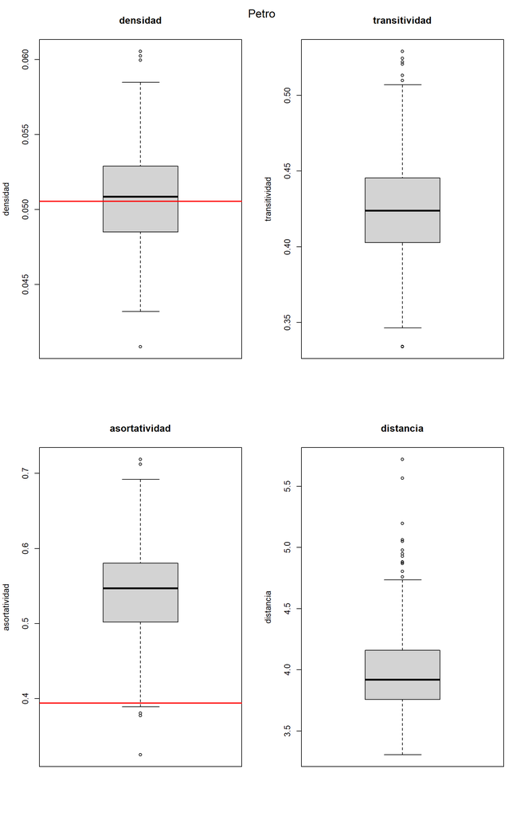

Figure 1.6: Comparación estadísticos en el modelo de bloques estocásticos para el gobierno de Petro

```r
graficar_gof(
    simulados = estadisticas_sim_sbm[[1]],
    observado = estadisticas_observadas[[1]],
    titulo = names(redes_poder)[1]
  )
```

#### 1.7.1.2 Duque

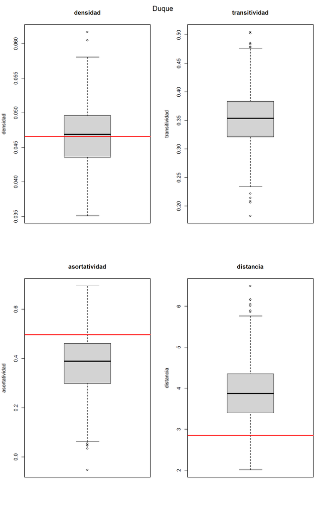

Figure 1.7: Comparación estadísticos en el modelo de bloques estocásticos para el gobierno de duque

```r
graficar_gof(
    simulados = estadisticas_sim_sbm[[2]],
    observado = estadisticas_observadas[[2]],
    titulo = names(redes_poder)[2]
  )
```

#### 1.7.1.3 Santos

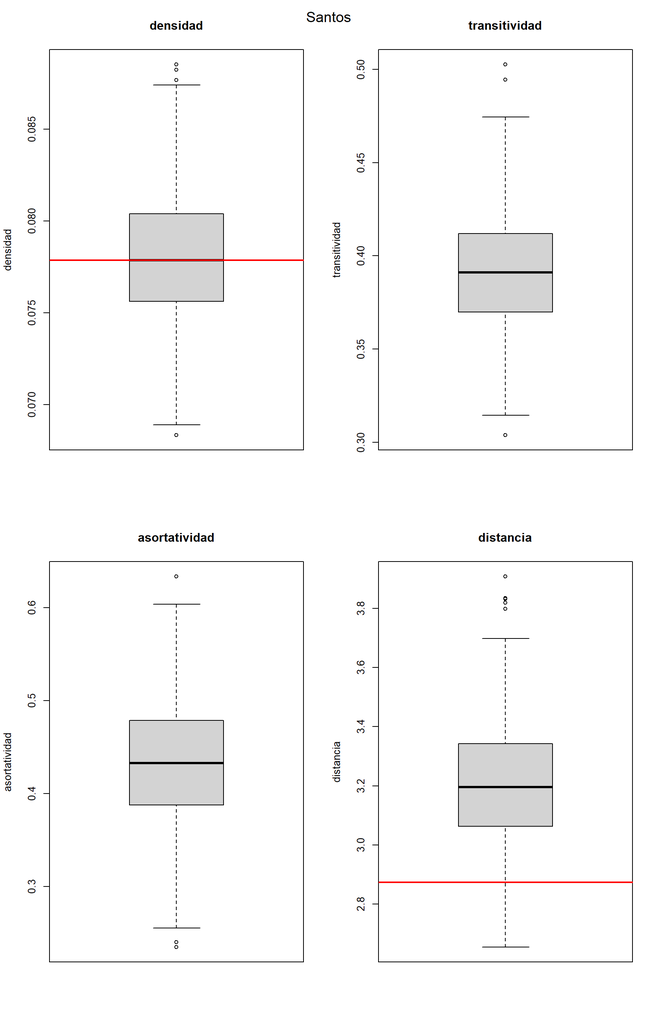

Figure 1.8: Comparación estadísticos en el modelo de bloques estocásticos para el gobierno de Santos

```r
graficar_gof(
    simulados = estadisticas_sim_sbm[[3]],
    observado = estadisticas_observadas[[3]],
    titulo = names(redes_poder)[3]
  )
```

#### 1.7.1.4 Uribe

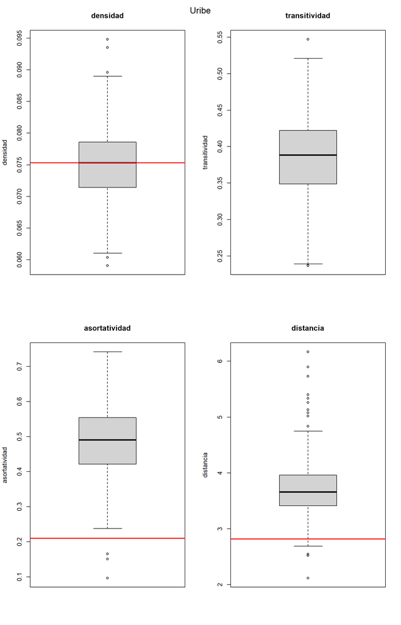

Figure 1.9: Comparación estadísticos en el modelo de bloques estocásticos para el gobierno de Uribe

```r
graficar_gof(
    simulados = estadisticas_sim_sbm[[4]],
    observado = estadisticas_observadas[[4]],
    titulo = names(redes_poder)[4]
  )
```

### 1.7.2 Modelos de grafos aleatorios exponenciales

#### 1.7.2.1 Petro

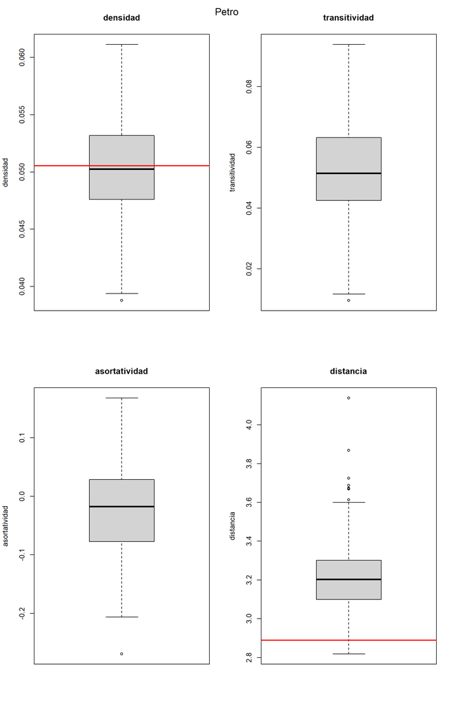

Figure 1.10: Comparación estadísticos en el modelo de grafos aleatorios exponenciales para el gobierno de Petro

```r
graficar_gof(
    simulados = estadisticas_sim_ergm[[1]],
    observado = estadisticas_observadas[[1]],
    titulo = names(redes_poder)[1]
  )
```

#### 1.7.2.2 Duque

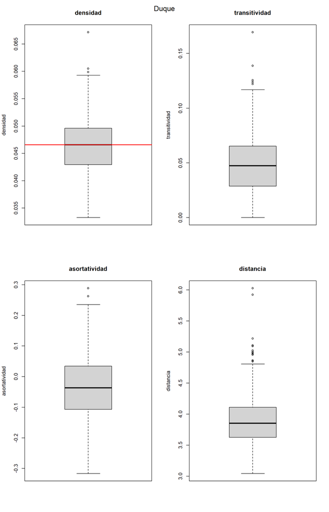

Figure 1.11: Comparación estadísticos en el modelo de grafos aleatorios exponenciales para el gobierno de Duque

```r
graficar_gof(
    simulados = estadisticas_sim_ergm[[2]],
    observado = estadisticas_observadas[[2]],
    titulo = names(redes_poder)[2]
  )
```

#### 1.7.2.3 Santos

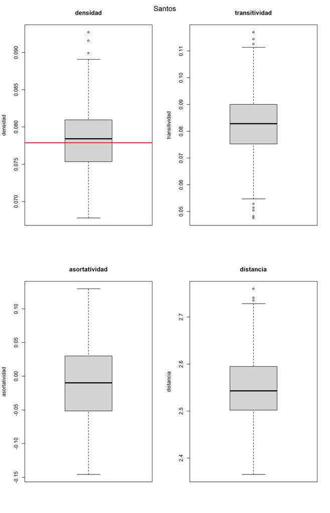

Figure 1.12: Comparación estadísticos en el modelo de grafos aleatorios exponenciales para el gobierno de Santos

```r
graficar_gof(
    simulados = estadisticas_sim_ergm[[3]],
    observado = estadisticas_observadas[[3]],
    titulo = names(redes_poder)[3]
  )
```

#### 1.7.2.4 Uribe

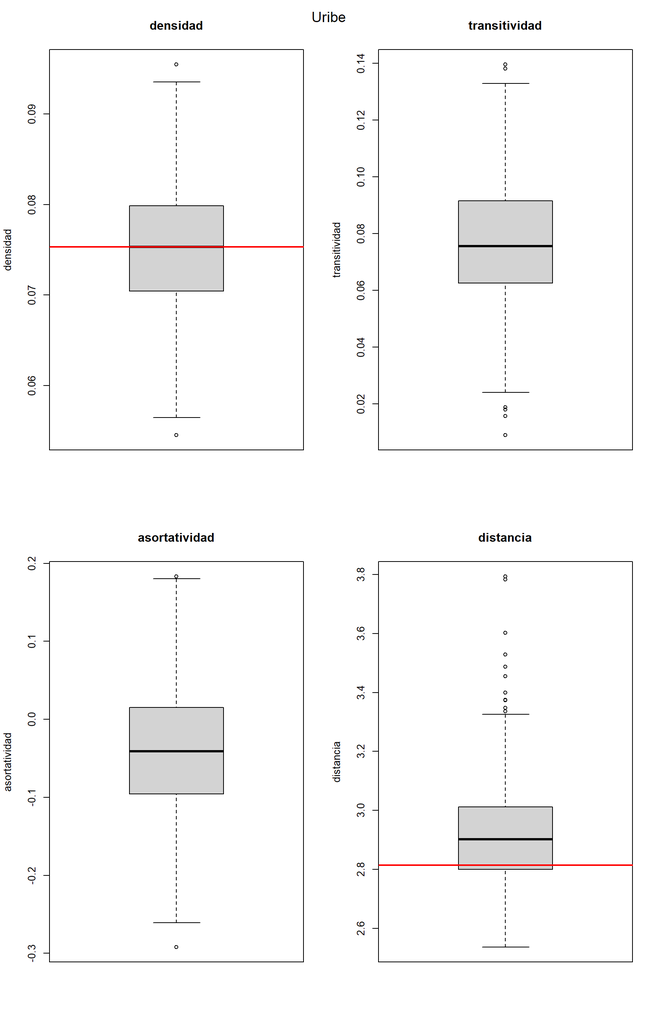

Figure 1.13: Comparación estadísticos en el modelo de grafos aleatorios exponenciales para el gobierno de Uribe

```r
graficar_gof(
    simulados = estadisticas_sim_ergm[[4]],
    observado = estadisticas_observadas[[4]],
    titulo = names(redes_poder)[4]
  )
```

#### 1.7.2.5 Discusión

- En todos los gobiernos, la **densidad** observada se encuentra dentro o muy cercana al rango intercuartílico de las redes simuladas, lo que indica que el modelo reproduce adecuadamente la proporción global de enlaces de las redes.
- En los cuatro gobiernos la **transitividad** y la **asortatividad** observada es considerablemente menor que la obtenida en las simulaciones. Esto indica que el modelo genera redes con una mayor tendencia al cierre triádico que la observada en los datos, es decir, sobreestima la formación de triángulos.
- La capacidad del modelo para reproducir la **distancia** es heterogénea entre gobiernos, ya que en algunos casos la red observada presenta valores inferiores a los simulados y en otros superiores. Hay una excepción con el gobierno de **Uribe** cuya obserbación se encuentra dentro del rango intercuartílico.

### 1.7.3 Modelos de sociabilidad con covariables

#### 1.7.3.1 Petro

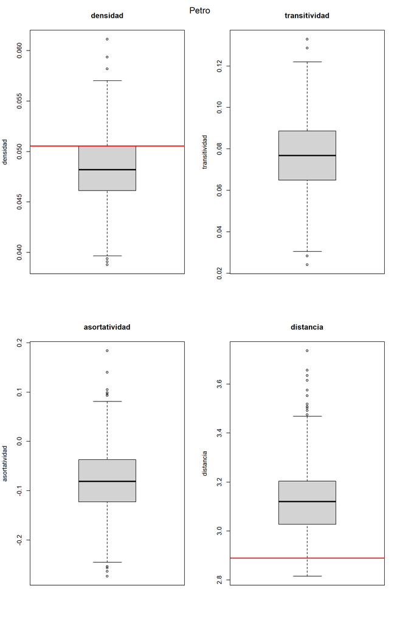

Figure 1.14: Comparación estadísticos en el modelo de sociabilidad con covariables para el gobierno de Petro

```r
graficar_gof(
    simulados = estadisticas_sim_ame[[1]],
    observado = estadisticas_observadas[[1]],
    titulo = names(redes_poder)[1]
  )
```

#### 1.7.3.2 Duque

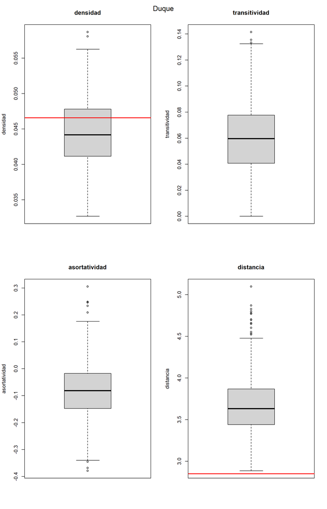

Figure 1.15: Comparación estadísticos en el modelo de sociabilidad con covariables para el gobierno de Duque

```r
graficar_gof(
    simulados = estadisticas_sim_ame[[2]],
    observado = estadisticas_observadas[[2]],
    titulo = names(redes_poder)[2]
  )
```

#### 1.7.3.3 Santos

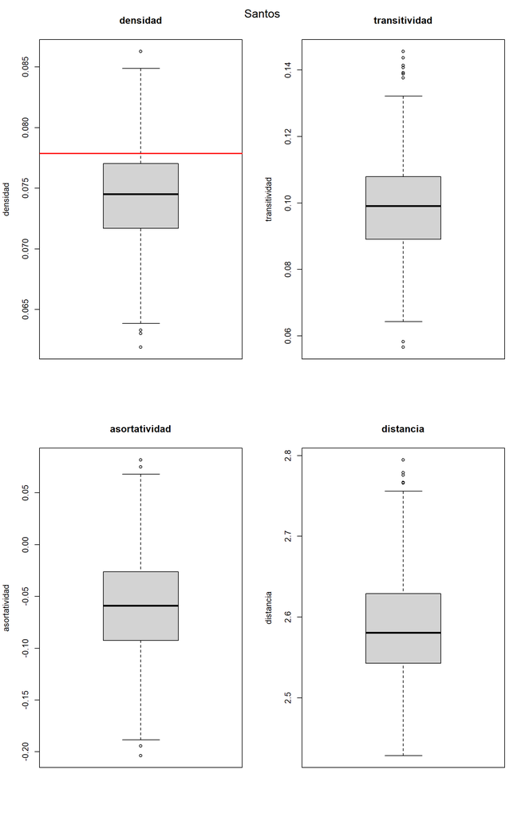

Figure 1.16: Comparación estadísticos en el modelo de sociabilidad con covariables para el gobierno de Santos

```r
graficar_gof(
    simulados = estadisticas_sim_ame[[3]],
    observado = estadisticas_observadas[[3]],
    titulo = names(redes_poder)[3]
  )
```

#### 1.7.3.4 Uribe

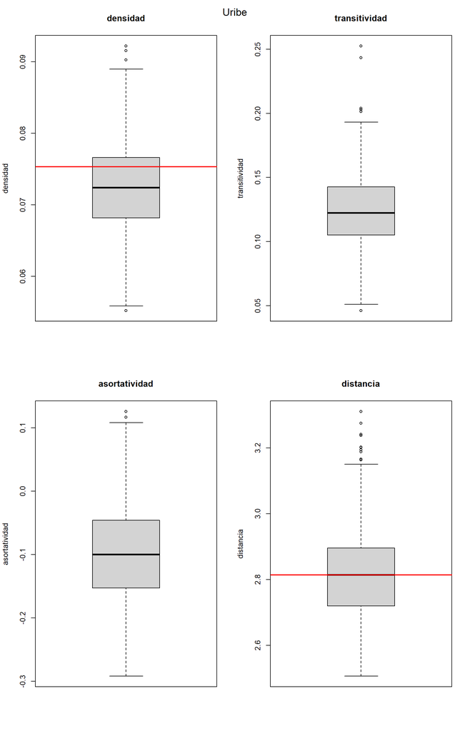

Figure 1.17: Comparación estadísticos en el modelo de sociabilidad con covariables para el gobierno de Uribe

```r
graficar_gof(
    simulados = estadisticas_sim_ame[[4]],
    observado = estadisticas_observadas[[4]],
    titulo = names(redes_poder)[4]
  )
```

#### 1.7.3.5 Discusión

- La capacidad del modelo para reproducir la **densidad** es heterogénea entre gobiernos, ya que en algunos casos la red observada presenta valores superiores y hay otros que estan dentro del rango intercuartílico indicando que en alguno casos (de acuerdo con las figuras 1.17 y 1.15) logra reproducir adecuadamente la proporción global de enlaces.
- En los cuatro gobiernos la **transitividad** y la **asortatividad** observada es considerablemente menor que la obtenida en las simulaciones. Esto indica que el modelo genera redes con una mayor tendencia al cierre triádico que la observada en los datos, es decir, sobreestima la formación de triángulos. Ocurre de manera similar con la **distancia** exceptuando el caso del gobierno de **Uribe** para el cual parece reproducir adecuadamente las distancias geodésicas.

## 1.8 g. Repita los numerales b., c. y d. para la red completa, sin filtrar por gobierno.

En cada pestaña se encuentra el respectivo análisis.

### 1.8.1 Visualizaicón decorada

```r
datos_gob <- poder  %>%
  mutate(
    partido_plot = case_when(
      PARTIDO_POLITICO %in% c("PACTO HISTORICO", "PACTO HISTÓRICO") ~ "Pacto Histórico",

      PARTIDO_POLITICO %in% c("CENTRO DEMOCRATICO", "CENTRO DEMOCRÁTICO") ~ "Centro Democrático",

      PARTIDO_POLITICO %in% c("PARTIDO LIBERAL",
                              "PARTIDO LIBERAL COLOMBIANO") ~ "Liberal",

      PARTIDO_POLITICO %in% c("PARTIDO CONSERVADOR",
                              "PARTIDO CONSERVADOR COLOMBIANO") ~ "Conservador",

      PARTIDO_POLITICO %in% c("PARTIDO DE LA U",
                              "PARTIDO SOCIAL DE UNIDAD NACIONAL") ~ "Partido de la U",

      PARTIDO_POLITICO %in% c("CAMBIO RADICAL") ~ "Cambio Radical",

      TRUE ~ "Otros"
    )
  )

  nombres <- poder[[1]]

  A <- datos_gob %>%
    select(all_of(entidades)) %>%
    mutate(across(everything(), as.numeric)) %>%
    as.matrix()

  rownames(A) <- nombres

  W <- A %*% t(A)

  Y_poder <- ifelse(W > 0, 1, 0)

  diag(Y_poder) <- 0


g_poder <- graph_from_adjacency_matrix(
    Y_poder,
    mode = "undirected",
    diag = FALSE
  )

  V(g_poder)$nombre <- datos_gob[[1]]
  V(g_poder)$partido <- datos_gob$partido_plot
  V(g_poder)$genero <- datos_gob$GENERO
  V(g_poder)$edad <- datos_gob$EDAD
  V(g_poder)$grado <- degree(g_poder)
```

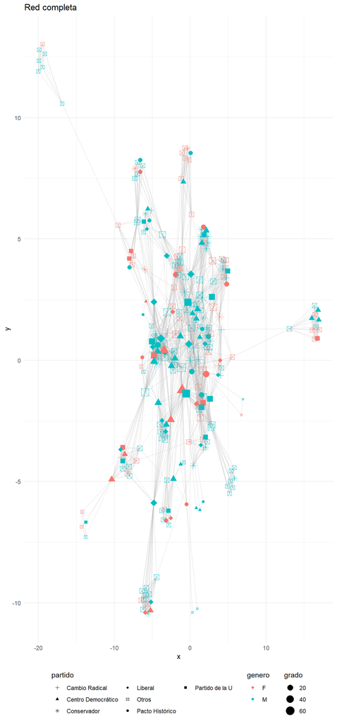

```r
ggraph(g_poder, layout = "fr") +

    geom_edge_link(
      alpha = .25,
      colour = "grey70"
    ) +

    geom_node_point(
      aes(
        colour = genero,
        shape = partido,
        size = grado
      )
    ) + scale_shape_manual(
  values = c(
    "Pacto Histórico" = 16,      # círculo
    "Centro Democrático" = 17,   # triángulo
    "Partido de la U" = 15,      # cuadrado
    "Liberal" = 18,              # rombo
    "Conservador" = 8,           # estrella
    "Cambio Radical" = 3,        # cruz
    "Otros" = 7                  # cuadrado con cruz
  )
) + guides(
  shape = guide_legend(nrow = 3, direction = "vertical"),
  colour = guide_legend(nrow = 2, direction = "vertical"),
  size=guide_legend(direction = "vertical") ) +

    labs(title = "Red completa") +

    theme_minimal() +

    theme(
      legend.position = "bottom"
    )
```

### 1.8.2 Centralidad

```r
medidas_1gcentralidad %>%
  kableExtra::kbl(
    caption = "Resultados",
    digits = 3
  ) %>%
  kableExtra::kable_minimal()
```

Table 1.17: Resultados

| Medidas | Media | Desviacion Estandar |
| --- | --- | --- |
| Grado | 0.058 | 0.034 |
| Cercania | 0.341 | 0.055 |
| Intermediacion | 0.008 | 0.021 |
| Propio | 0.171 | 0.222 |

La red completa presenta un grado medio de 0.058, indicando que, en promedio, cada actor se encuentra conectado con una pequeña proporción del total de funcionarios. La cercanía promedio es de 0.341 y muestra una baja variabilidad (desviación estándar de 0.055), lo que sugiere que la capacidad de alcanzar al resto de los actores es relativamente homogénea entre los nodos de la red. Por su parte, la intermediación promedio continúa siendo baja (0.008), indicando que la mayoría de los funcionarios no actúa como puente entre otros actores. Finalmente, la centralidad de vector propio presenta la mayor variabilidad (media de 0.171 y desviación estándar de 0.222), lo que evidencia que unos pocos actores concentran una posición privilegiada al estar conectados con otros nodos altamente centrales, mientras que la mayoría posee valores reducidos de esta medida.

### 1.8.3 Análisis Local y estructural

#### 1.8.3.1 Distancia

```r
tabla1cdistancia %>%
  kableExtra::kbl(caption='Resultados',
                  digits=3) %>%
  kableExtra::kable_minimal()
```

Table 1.18: Resultados

| Medidas.departamento | valor |
| --- | --- |
| Orden | 265 |
| Tamaño | 2031 |
| Orden de la componente gigante | 265 |
| Diámetro del grafo | 7 |
| Camino del diámetro | ANGELA YESENIA OLAYA REQUENE;MARIA DEL ROSARIO GUERRA DE LA ESPRIELLA;CARINA MURCIA YELA;JUAN CARLOS ESGUERRA PORTOCARRERO;CARLOS HOLMES TRUJILLO GARCIA;AURORA VERGARA FIGUEROA;MAURICIO PERFETTI DEL C… |
| distancia media | 3.022 |

A diferencia de las redes individuales por gobierno, la red completa es conexa, ya que la componente gigante incluye la totalidad de los 265 nodos. Además, el aumento en el tamaño de la red no implica un incremento importante en las distancias entre actores: la distancia media es de aproximadamente tres pasos y el diámetro permanece en siete, valores muy similares a los obtenidos para cada gobierno por separado. Esto sugiere que, al considerar conjuntamente todos los funcionarios, la red mantiene una estructura relativamente compacta, en la que los actores pueden alcanzarse mediante pocos intermediarios.

#### 1.8.3.2 Cohesión

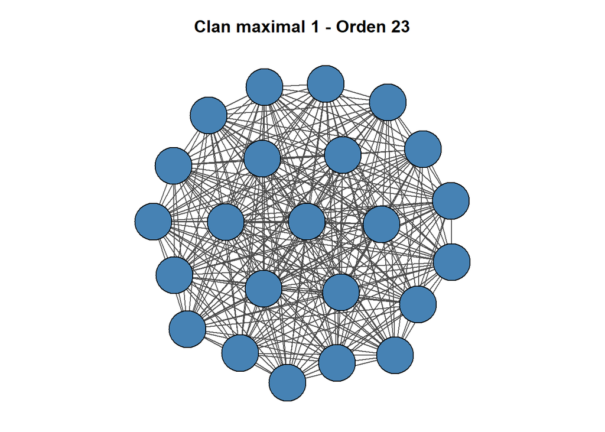

```r
tabla_cliques <- sapply(
  X = seq_len(clique_num(g_poder)),
  FUN = \(k) {
    count_max_cliques(g_poder, min = k, max = k)
  }
)

tabla_cliques <- data.frame(
  clique = seq_along(tabla_cliques),
  frecuencia = tabla_cliques
)

tabla_cliques <- dplyr::filter(
  tabla_cliques,
  frecuencia != 0
)

clanes_maximales <- largest_cliques(g_poder)

par(mfrow = c(1, 1), mar = c(1, 1, 3, 1))

for (k in seq_along(clanes_maximales)) {

  clan_maximal <- induced_subgraph(
    g_poder,
    vids = clanes_maximales[[k]]
  )

  plot(
    clan_maximal,
    main = paste(
      "Clan maximal",
      k,
      "- Orden",
      vcount(clan_maximal)
    ),
    vertex.size = 25,
    vertex.label = "",
    vertex.color = "steelblue",
    vertex.frame.color = "black",
    edge.color = "gray30"
  )
}
```

```r
comp <- components(g_poder)

giant_id <- which(comp$membership == which.max(comp$csize))

g_gc <- induced_subgraph(
  g_poder,
  giant_id
)

densidad2c <- data.frame(
  Red=c("Componente gigante","Red completa"),
  Densidad = c(edge_density(g_gc),edge_density(g_poder))
)
```

```r
tabla_cliques %>%
    kableExtra::kbl(
      caption = "Clanes y su Frecuencia para toda la red",
      digits = 3,
      format = 'html'
    ) %>%
    kableExtra::kable_minimal()
```

Table 1.19: Clanes y su Frecuencia para toda la red

| clique | frecuencia |
| --- | --- |
| 2 | 3 |
| 3 | 13 |
| 4 | 17 |
| 5 | 9 |
| 6 | 6 |
| 7 | 3 |
| 9 | 2 |
| 10 | 5 |
| 11 | 2 |
| 12 | 1 |
| 13 | 3 |
| 14 | 1 |
| 15 | 3 |
| 16 | 1 |
| 17 | 2 |
| 19 | 1 |
| 23 | 1 |

En la red completa se observa una mayor diversidad en el tamaño de los cliques maximales. Aunque predominan los cliques pequeños, especialmente de tres y cuatro actores, también se identifican grupos altamente cohesionados de gran tamaño, alcanzando hasta 23 actores. Esto indica que, al integrar los cuatro gobiernos en una única red, emergen comunidades más amplias cuyos miembros se encuentran completamente conectados entre sí.

```r
densidad2c %>%
  kableExtra::kbl(
    caption = "Densidad de las componentes gigantes de la red completa",
    digits = 3
  ) %>%
  kableExtra::kable_minimal()
```

Table 1.20: Densidad de las componentes gigantes de la red completa

| Red | Densidad |
| --- | --- |
| Componente gigante | 0.058 |
| Red completa | 0.058 |

La densidad de la componente gigante coincide con la de la red completa (0.058), debido a que toda la red forma una única componente conexa. En términos generales, la red es relativamente dispersa, ya que solo alrededor del 5.8 % de las conexiones posibles están presentes. Sin embargo, esta baja densidad global no impide la existencia de cliques de gran tamaño, lo que evidencia la presencia de subgrupos altamente cohesionados dentro de una estructura general más dispersa.

#### 1.8.3.3 Conectividad

```r
tabla.1cconectividad %>%
  kableExtra::kbl(caption = 'Métricas de conectividad',
                    digits = 3) %>%
  kableExtra::kable_minimal()
```

Table 1.21: Métricas de conectividad

| Medidas | Valores |
| --- | --- |
| ¿Está conectado | TRUE |
| Conectividad nodal | 1 |
| Conectividad por aristas | 1 |
| Puntos de artículación | FRANCIA ELENA MARQUEZ MINA;GUILLERMO ANTONIO HERRERA CASTANO;CIELO ELAINNE RUSINQUE URREGO;MARIA DEL ROSARIO GUERRA DE LA ESPRIELLA;MAURICIO PERFETTI DEL CORRAL;AURORA VERGARA FIGUEROA;JUAN MANUEL SAN… |

A diferencia de las redes individuales por gobierno, la red completa es conexa, por lo que existe al menos un camino entre cualquier par de actores. En consecuencia, la conectividad nodal y la conectividad por aristas toman el valor de 1. Esto indica que la eliminación de un único nodo o de una única arista es suficiente para desconectar la red, por lo que, aunque la red está completamente conectada, presenta una baja robustez estructural frente a la pérdida de actores o vínculos clave.

#### 1.8.3.4 Agrupamiento

```r
# Transitividad local
tabla_1c_transitividadg <- transitivity(
  graph = g_poder,
  type = "local"
)

tabla_1c_transitividadg[is.nan(tabla_1c_transitividadg)] <- NA

# Transitividad global
trans_global <- transitivity(
  graph = g_poder,
  type = "global"
)

# Datos para el histograma
df <- data.frame(
  transitividad = tabla_1c_transitividadg
)

# Gráfico
grafico_transitividad <-
  ggplot(df, aes(x = transitividad)) +
  geom_histogram(
    col = "gray24",
    fill = "steelblue"
  ) +
  labs(
    title = "Distribución de la transitividad local",
    x = "Transitividad local",
    y = "Frecuencia"
  ) +
  geom_vline(
    aes(
      xintercept = trans_global,
      color = "Global"
    ),
    linewidth = 1.2
  ) +
  annotate(
    "text",
    x = trans_global,
    y = Inf,
    label = round(trans_global, 3),
    vjust = 2,
    color = "black"
  ) +
  scale_color_manual(
    name = "",
    values = c(Global = "gray49")
  ) +
  theme_minimal()
```

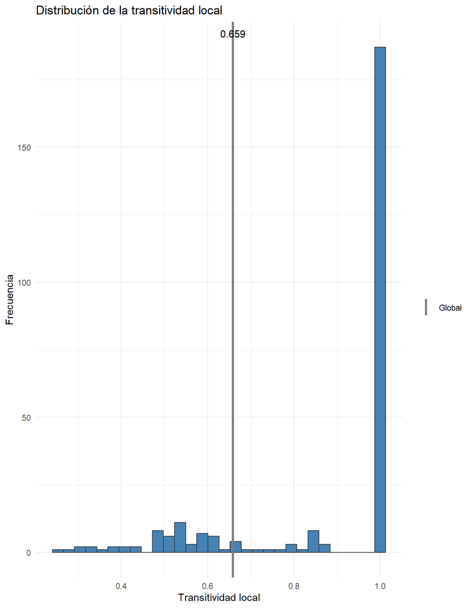

Figure 1.18: Distribución de la transitividad local en la red completa

```r
grafico_transitividad
```

La red completa presenta una transitividad global de 0.659, lo que indica una elevada tendencia a la formación de triángulos y, por tanto, de grupos de actores cuyos vecinos también se encuentran conectados entre sí. Asimismo, la distribución de la transitividad local presenta un sesgo hacia la izquierda, evidenciando que la mayoría de los nodos posee coeficientes de transitividad relativamente altos, mientras que son pocos los actores con valores bajos. Esto sugiere que el agrupamiento local es una característica predominante de la red.

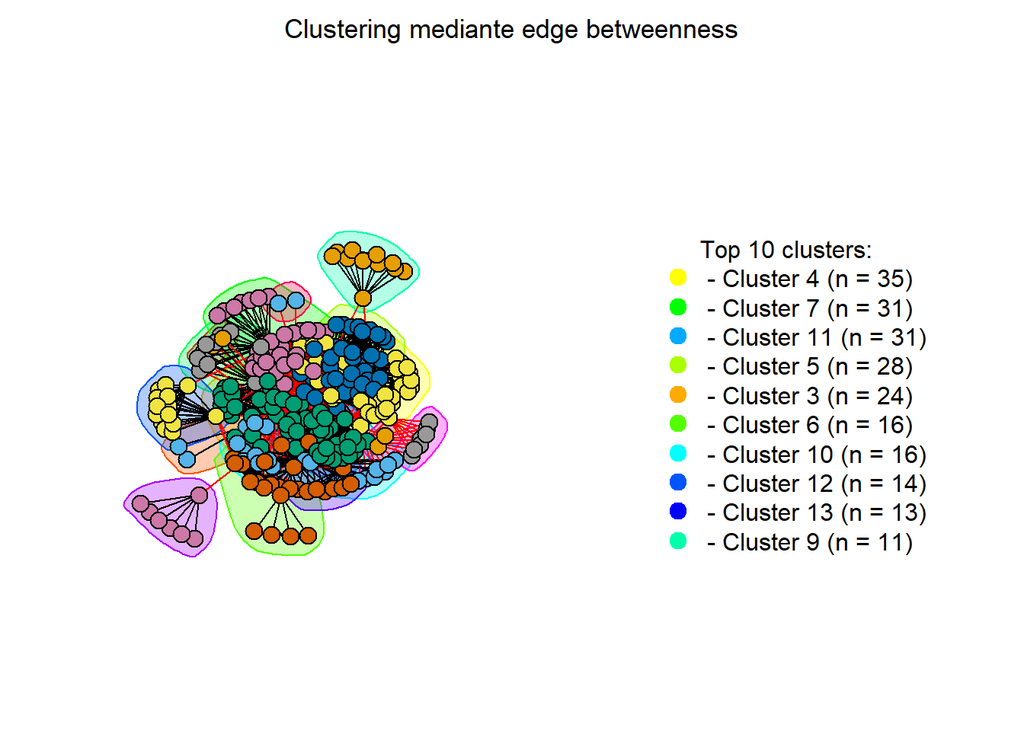

# 2 Estructuras sociales cognitivas

El trabajo de David Krackhardt en la década de 1980 fue pionero en la identificacion de individuos con habilidades para percibir la estructura social en la que están inmersos. Para ello, recopilo datos relacionales sobre la estructura social cognitiva (Cognitive Social Structure, CSS, por sus siglas en inglés) de 21 miembros del personal administrativo de una empresa de fabricacion de maquinaria de alta tecnología, Silicon Systems. El objetivo era evaluar los efectos de un programa reciente de intervencion administrativa. Una de las relaciones estudiadas fue la amistad, donde cada persona no solo reporto sus relaciones de amistad, sino también las relaciones percibidas entre todos los demás empleados. Esto permitio construir una matriz de adyacencia de tamaño $21\times21$ que reflejaba las percepciones de cada individuo dentro del grupo. Este enfoque ha sido utilizado con éxito en estudios posteriores mediante modelos triádicos (e.g., Sosa y Rodríguez 2021).

Para replicar los hallazgos de Krackhardt, así como de otros autores que han estudiado las estructuras sociales cognitivas (CSSs), considere el conjunto de datos *CSS2022.txt*. Este archivo contiene las percepciones de amistad de los estudiantes de un curso ofrecido por el Departamento de Estadística de la Universidad Nacional de Colombia durante el segundo semestre de 2022.

La red de consenso de una CSS se define como la red cuya matriz de adyacencia, denotada por $\mathbf{A}=[a_{i,j}]$, se construye aplicando la siguiente regla:
$$\begin{cases}
1,\text{ si}\frac{1}{I}\sum_{k=1}^{I}a_{i,j,k}>0.25 & \\
0,\text{ en otro caso},
\end{cases},$$
donde $I$ es el número total de actores en el sistema, y $a_{i,j,k}$ es la percepcion del actor $k$ sobre la relacion entre los actores $i$ y $j$.

Este enfoque permite sintetizar las percepciones individuales en una única red que refleja el consenso del sistema social en cuestion.

## 2.1 a.Realice visualizaciones no decoradas en un diseño circular para representar todas las percepciones individuales y la red de consenso. Compare las diferencias entre las percepciones individuales y entre estas y la red de consenso, identificando posibles discrepancias o patrones consistentes. Use tantas tablas y gráficos como sean necesarios para apoyar el análisis. Interprete los resultados obtenidos, evaluando la coherencia entre las percepciones y la capacidad del consenso para capturar el panorama general del sistema social, limitando el análisis a un máximo de 1000 palabras.

### 2.1.1 Actor 1 y 2.

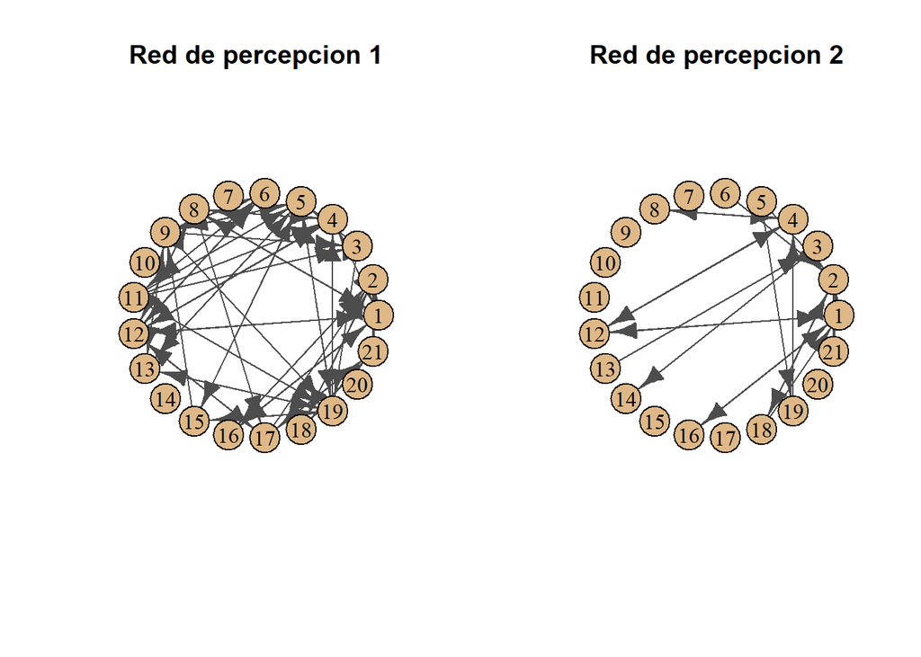

### 2.1.2 Actores 3 y 4

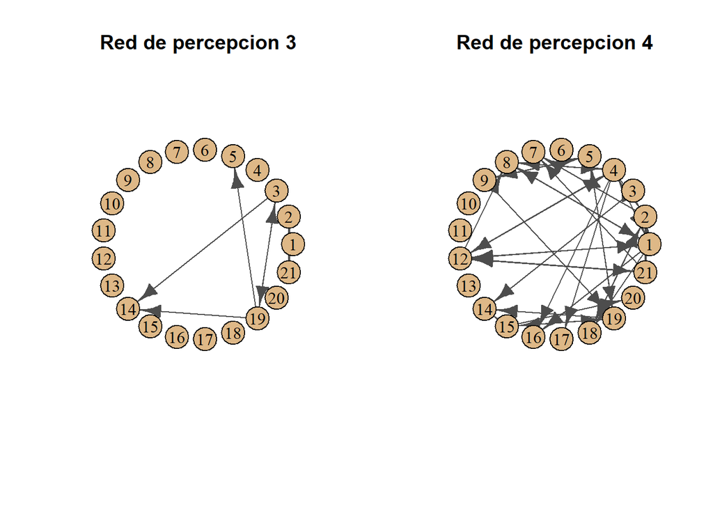

### 2.1.3 Actores 5 y 6

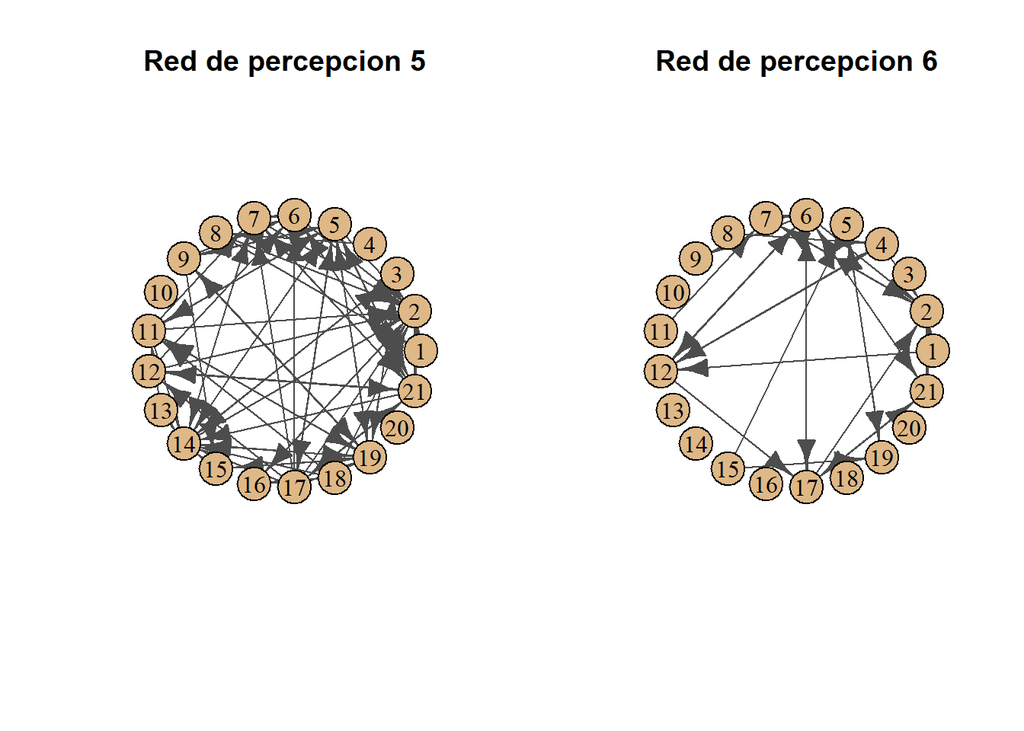

### 2.1.4 Actores 7 y 8

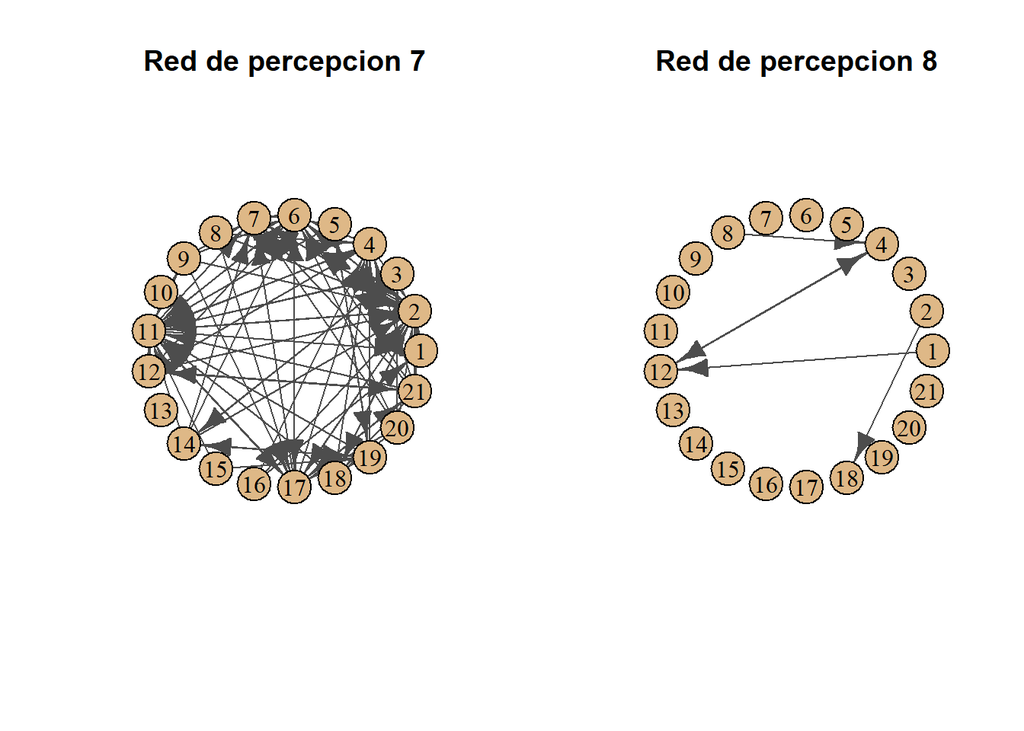

### 2.1.5 Actores 9 y 10

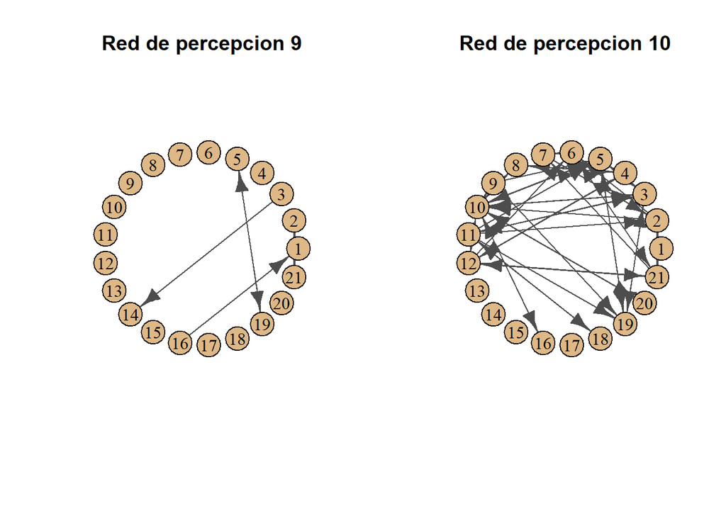